# DBERlibR: Automated Assessment Data Analysis

HelikarLab

6/30/2022

This is a documentation of DBERlibR, which represents Discipline-based Education Research library R. The package runs R scripts to clean the data, merge/bind multiple datasets (as necessary), check assumption(s) for a specific statistical technique (as necessary), run the main assessment data analysis, and export the analysis output(s) all at once. The output(s) contain(s) a sample interpretation of the results for the convenience of users. Users need to prepare the data file as instructed, save it in the folder designated as a working directory in RStudio, load all dependencies, and type a function in the R console to conduct a specific data analysis.

## Package Installation

The “DBERlibR” package is currently published on GitHub, so you need to follow the steps to install a package from GitHub, as instructed below. Please make sure to have the newest version of R (https://cloud.r-project.org/) and the most recent RStudio (https://www.rstudio.com/products/rstudio/download/) installed on your machine before proceeding.

1. First, you need to install the “devtools” package in your RStudio if you haven’t done so yet. Refer to the instructions for installing devtools, available at https://www.r-project.org/nosvn/pandoc/devtools.html. You can do this from CRAN; just copy/type the line below in your R console and hit the Enter key.

```r
install.packages("devtools", repos="http://cran.us.r-project.org")
```

2. You need to have a working development environment before loading the package “devtools” in RStudio. Please follow Step 2 in the instruction on devtools linked above. For example, you need to download and install RTools if the operating system of your machine is Windows; follow the instruction available https://cran.r-project.org/bin/windows/Rtools/rtools40.html (You may want to refer to a YouTube video on how to install RTools40: e.g., https://www.youtube.com/watch?v=njZBf34Akgo).
3. Once you have a working development environment, load the “devtools” package in RStudio; just copy/type the line below in your R console and hit the Enter key.

```r
library(devtools)
```

4. Now you’re ready to install the package “DBERlibR” from GitHub. In most cases, you just use install_github(“author/package”). So, you can just copy/type the line below in your R console and hit the Enter key.

```r
install_github("HelikarLab/DBERlibR", repos="http://cran.us.r-project.org")
```

If you get the question, “Do you want to install from sources the package which needs compilation?”, this often means that the package has been updated recently on CRAN but the binary isn’t yet available for your OS (can take a day or two). There are probably other scenarios when the binary isn’t available for your platform. If you say no, you won’t get the most recent version. But this might be just fine unless you were specifically installing because of an update. If you say yes, the package will be built from source locally. If it has compiled code and you’ve never set up build tools for R, then this won’t actually succeed.

If you fail to install the package due to an error related to the package of “rlang,” you need to first remove it (run remove.packages(“rlang”) in the R console) and then install it again (run install.packages(“rlang”) in the R console). Then try Step 4 again.

## Load DBERlibR, Set Working Directory, and Save Data File(s) in that Directory

Load DBERlibR by typing/copying the line below in the R console and hitting the Enter key.

```r
library(DBERlibR)
```

Then, you need to set “Working Directory” under the “Session” menu in R Studio. The directory should be a folder where (all) data file(s) is(are) saved because the functions in this package import accurately named data file(s) from the working directory. Please download the sample data folder (4 csv files in it) from “https://github.com/HelikarLabPersonal/DBERlibR” to test the package. You need to add a GitZip extension to your browser to download a folder from GitHub (refer to a YouTube video on how to do it: https://www.youtube.com/watch?v=6dnzDILMobU). Once downloaded unzipped, save all 4 csv files in the working directory you’ve set.

## Data Preparation

The data should include only (student) id and questions (no other data like demographic information; you should save other data in a separate file along with id if you have them). The question data should be binary (i.e., 1 for correct answers, 0 for incorrect answers); if your data contains multiple-choice answers, you must transform them into binary data. For your reference, the data file should look like the sample below. The data file should be in the “csv” format.

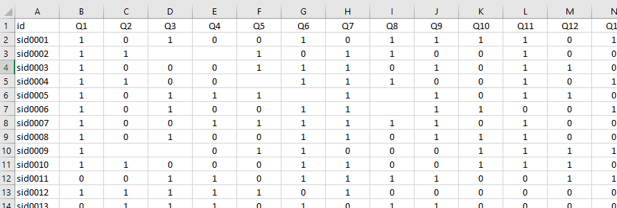

assessment data Format

As you can see in the data table above, the questions were named Q1, Q2, Q3, and so on, but you can name the questions differently; please make sure to use the same question name across different datasets (i.e. treatment group pre-test data, treatment group post-test data, control group pre-test data, and control group post-test data). Blank cells indicate skipped answers; these blank cells will be treated as incorrect in the process of data preparation. Please do not fill the blank cells (i.e., skipped answers) with any simbol (e.g., “NA”, “99”); those simbols will cause an error in data preparation/analysis. An csv data file exported from online survey platform like Qualtrics may contain two header rows (one for question number and another for question wordings); you need to leave only one header with id and question numbers. Please open the sample data files to see how they are prepared consistently.

You need to save the data file exactly the same as the sample data files (use the same file names): “data_treat_pre.csv” for the treatment group’s pre-test data; “data_treat_post.csv” for the treatment group’s post-test data; “data_ctrl_pre.csv” for the control group’s pre-test data; and “data_ctrl_post.csv” for the control group’s post-test data.

Skipped answers in the data file(s) (i.e., blank cells in the dataframe above) will be treated as incorrect in this package. Too many skipped answers may skew the results of data analysis. Users can exclude students with too many skipped answers by defining too many skipped answers; you can just provide a percentage as a response to the following prompt (You need to respond to this prompt whenever you run a function in this package):

```
## [1] "Please enter a percentage (e.g., 10%, 25%): "
```

If you have students’ demographic information and want to examine the differences of demographic subgroups (e.g., male vs. female), you should save other data in a separate file along with id (the same id as in the assessment data file(s)). Although The data format should look like the one below. Please DO NOT convert the subgroup label to a numeric code; it will be hard to read the results if you use a numeric code.

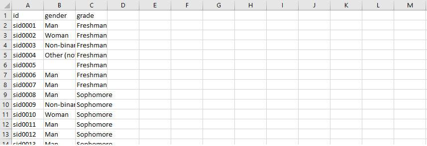

Demographic Data Format

## Item Analysis Function: “itemanalysis()”

The item analysis function requires users to type a data file name as shown in the sample code below. You can input any of the data file names (i.e., “data_treat_pre.csv”, “data_treat_post.csv”, “data_ctrl_pre.csv”, or “data_ctrl_post.csv”) as they become available for item analysis.

```r
# You can copy and paste the following function into the console panel of RStudio: itemanalysis("data_treat_pre.csv"), itemanalysis("data_ctrl_pre.csv"), itemanalysis("data_treat_post.csv"), or itemanalysis("data_ctrl_pre.csv")
```

The function will display a message and prompt to determine ‘students with too many skipped answers’ to be excluded from data analysis. Once you respond to this prompt (i.e., either provide an alternative rate or just hit the Enter key), the function automatically reads and cleans the data (e.g., deleting students with too many skipped answers, converting missing values to “0”), calculates difficulty and discriminant scores, displays all results in the Console and Plots panels of RStudio, and exports the results to an Excel file, which is saved in the working directory. The Excel file name follows the data file name used for item analysis; for example, if you’ve input “data_treat_pre.csv” in the function, then the output Excel file name contains “treat_pre.” The function also generates plots in the jpeg file format to visualize the results; the jpeg file name follows the data file name as well so that you can easily find the results of the item analysis you’ve just run.

Item difficulty refers to the proportion of students that correctly answered the item, scaled 0 to 1. Ideal values are known to be slightly higher than midway between a chance to be chosen (i.e., 1 divided by the number of choices) and a perfect score (1) for the item. In common, values below 0.2 are considered to indicate “very difficult” items and need to be reviewed for possible confusing language, removed from the test, and/or identified as an area for re-instruction to improve test instruments. In addition to improving the test instrument, the results of item difficulty analysis inform the areas of weakness in students’ knowledge to be taken into consideration in improving teaching modules. The difficulty plot is shown below.

```
## Item Analysis Results - Difficulty
```

```
##     q.number difficulty_index
## 1         Q1             0.86
## 2         Q2             0.44
## 3         Q3             0.70
## 4         Q4             0.36
## 5         Q5             0.46
## 6         Q6             0.62
## 7         Q7             0.60
## 8         Q8             0.48
## 9         Q9             0.64
## 10       Q10             0.58
## 11       Q11             0.70
## 12       Q12             0.60
## 13       Q13             0.36
## 14       Q14             0.54
## 15       Q15             0.78
## 16       Q16             0.72
## 17       Q17             0.64
## 18       Q18             0.38
## 19       Q19             0.58
## 20       Q20             0.56
## 21       Q21             0.38
## 22       Q22             0.52
## 23 avg_score             0.57
```

```
## The result above has been exported to an Excel file, of which file name includes 'itemanalysis_outputs,' in the working directory.
```

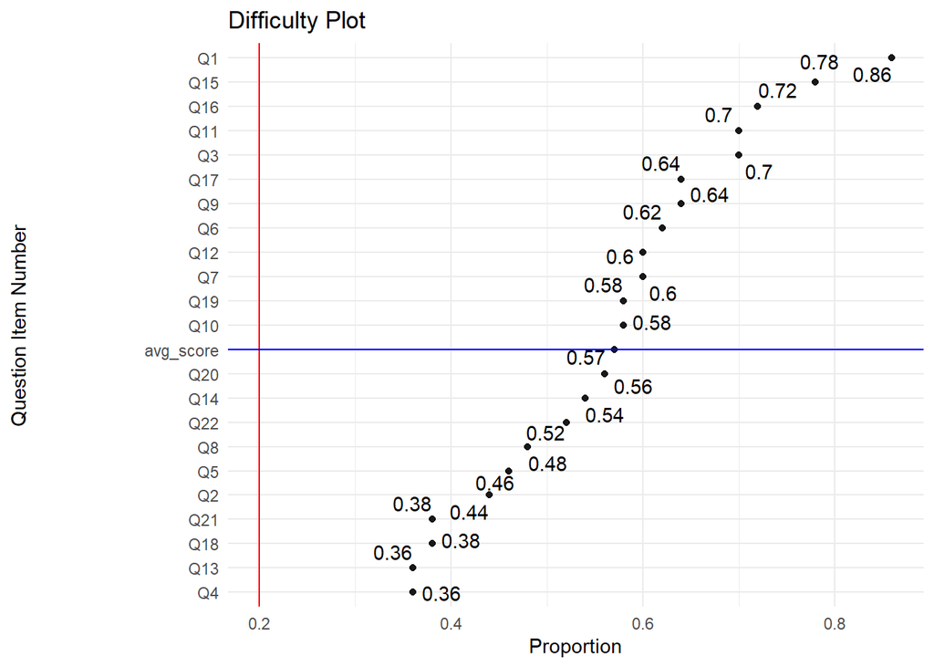

```
## Refer to 'Difficulty Plot' in the 'Plots' panel. The plot has also been exported to an image file, of which file name includes 'itemanalysis_difficulty_plot,' in the working directory.
```

```
## As seen in the difficulty plot, none of the difficulty indixes was found to be lower than 0.2.
```

The proportions in the generated difficulty plot above are ordered by their size, and the plot displays a vertical red-colored line that represents the threshold of 0.2 so that you can instantly find the question items that warrant your attention for improvement. The plot above does not have any item of which proportion size is below 0.2.

```
## Item Analysis Results - Discrimination:
```

```
##      qnumber discrimination_index
## 1         Q1                -0.12
## 2         Q2                -0.25
## 3         Q3                 0.15
## 4         Q4                 0.08
## 5         Q5                -0.16
## 6         Q6                 0.09
## 7         Q7                 0.08
## 8         Q8                 0.19
## 9         Q9                 0.33
## 10       Q10                 0.14
## 11       Q11                 0.30
## 12       Q12                 0.29
## 13       Q13                 0.53
## 14       Q14                 0.16
## 15       Q15                 0.17
## 16       Q16                 0.48
## 17       Q17                -0.06
## 18       Q18                 0.57
## 19       Q19                 0.31
## 20       Q20                 0.55
## 21       Q21                 0.30
## 22       Q22                 0.28
## 23 avg_score                 1.00
```

```
## The result above has been exported to an Excel file, of which file name includes 'itemanalysis_outputs,' in the working directory.
```

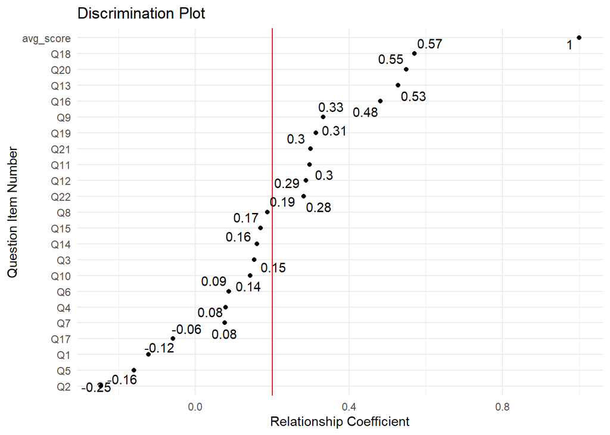

```
## Refer to 'Discrimination Plot' in the 'Plots' panel. The plot has also been exported to an image file, of which file name includes 'itemanalysis_discrimination_plot,' in the working directory.
```

```
## As seen in the discrimination plot, the following question items present a discrimination index lower than 0.2:
##  [1] "Q1"  "Q2"  "Q3"  "Q4"  "Q5"  "Q6"  "Q7"  "Q8"  "Q10" "Q14" "Q15" "Q17"
```

The relationship coefficients in the generated discrimination plot are ordered by their size, and the plot displays a vertical red-colored line that represents the threshold of 0.2 so that you can instantly find the question items that warrant your attention for improvement. The plot above presents 12 question items of which coefficients are less than 0.2.

## Paired Samples Data Analysis Function: “pairedsamples()”

An ideal situation for examining the effect of teaching modules on student performance (i.e., pre-post difference) is to have a control group to compare with the treatment/intervention group (use onewayancova() function if you have all four datasets). However, it is often difficult to get the control group data. If that is the case, you can use this function to examine the difference between pre-test and post-test scores of the treatment group. Please make sure to name data files accurately (i.e., “data_treat_pre.csv”,“data_treat_post.csv”) and have them saved in the working directory.

```r
# You can copy and past the following function in the console panel of RStudio: pairedsamples()
```

The “pairedsamples()” function automatically cleans the datasets (e.g., converting missing values to “0), merges pre-post datasets, runs the Paired Samples T-test (Parametric) and Wilcoxon Signed-Rank test (Nonparametric), and then exports outputs to help you examine the difference between pre-post scores. The outputs of the”pairedsamples()” function are as follows.

First, a summary of pre-/post-test scores’ descriptive statistics will be presented in the R console (and exported to a text file named “pairedsamples_outputs”).

```
## # A tibble: 2 × 11
##   Time  variable     n   min   max median   iqr  mean    sd    se    ci
##   <fct> <chr>    <dbl> <dbl> <dbl>  <dbl> <dbl> <dbl> <dbl> <dbl> <dbl>
## 1 Pre   Score       45 0.364 0.773  0.545 0.136 0.572 0.097 0.014 0.029
## 2 Post  Score       45 0.364 0.864  0.636 0.136 0.655 0.111 0.017 0.033
```

Then, boxplots will be presented in the ‘Plots’ panel in RStudio (and also exported to an image file named “pairedsamples_boxplots”) to help you visually inspect the descriptive statistics.

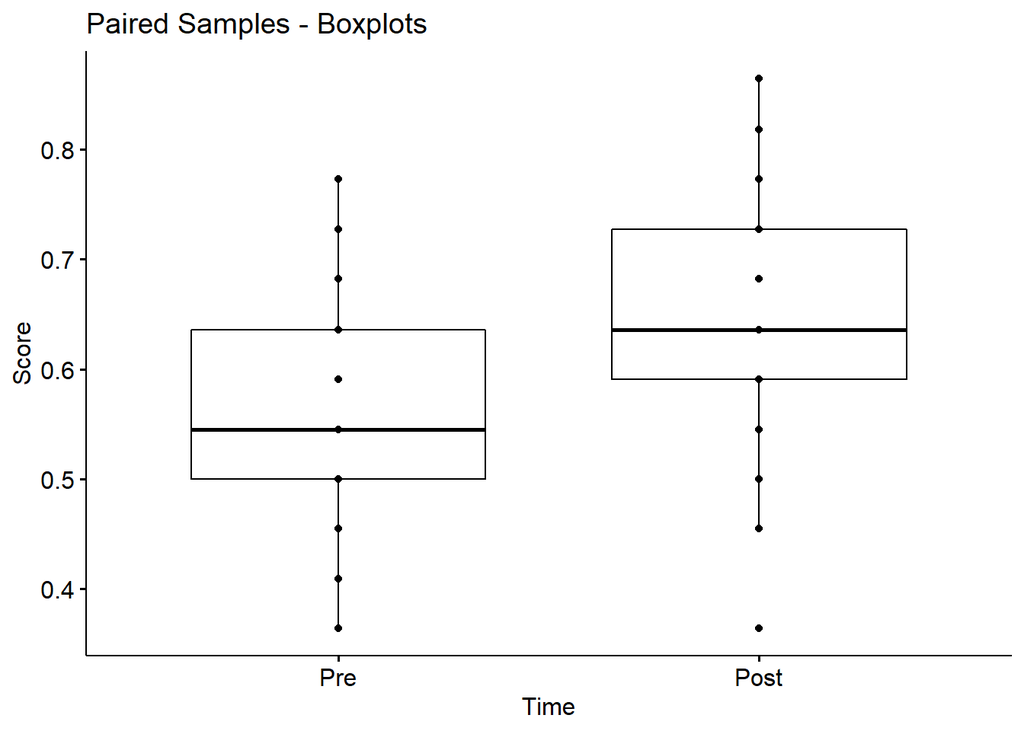

Second, the function run scripts to check the assumptions to be satisfied for using the paired samples t-test and present the results in the R console (and exports the results to the working directory (i.e., no outliers and normal distribution of of mean differences). For example, you can see the result of the Shapiro-Wilk normality test in your R console (followed by a brief interpretation of the result: e.g., “the assumption of normality by group has NOT been met (p<0.05)) and the histogram and normal Q-Q plot of the mean differences, as shown below.

```
## # A tibble: 1 × 3
##   variable statistic      p
##   <chr>        <dbl>  <dbl>
## 1 avg_diff     0.952 0.0607
```

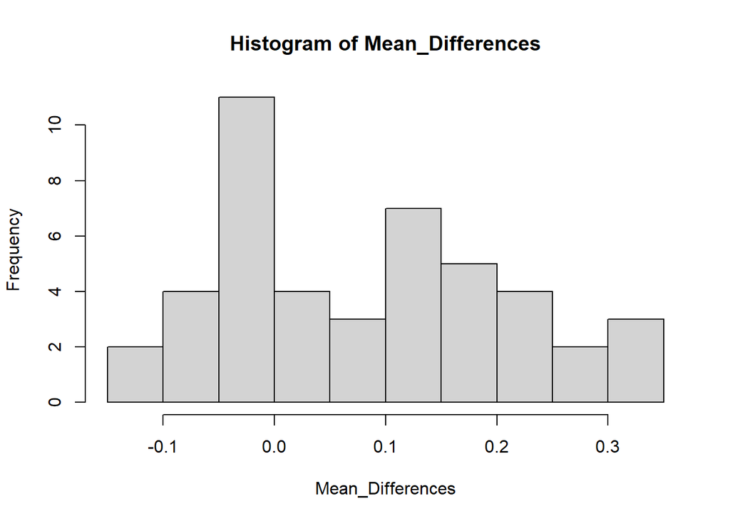

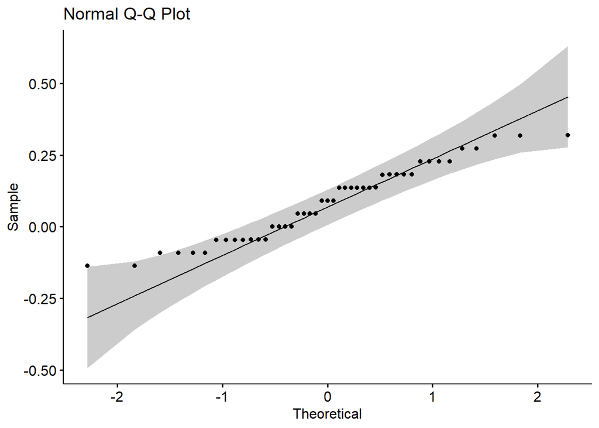

```
##
##  Paired t-test
##
## data:  treat_data_merged$avg_score_pre and treat_data_merged$avg_score_post
## t = -4.2903, df = 44, p-value = 9.625e-05
## alternative hypothesis: true mean difference is not equal to 0
## 95 percent confidence interval:
##  -0.12319734 -0.04444711
## sample estimates:
## mean difference
##     -0.08382222
```

Fourth, if the sample size is considered to be too small (e.g., less than 15), or the data has failed to satisfy the normality assumption for using the parametric paired samples t-test, then the function automatically runs the Wilcoxon signed rank sum test (a non-parametric version of the paired samples t-test) and presents its results in the R console (and exports them to the output text file as well), as shown below (hence, you won’t be able to see the non-parametric test result if you can use the parametric test result, since the parametric test is more powerful than its non-parametric alternative).

```
##
##  Wilcoxon signed rank test with continuity correction
##
## data:  treat_data_merged$avg_score_pre and treat_data_merged$avg_score_post
## V = 146.5, p-value = 0.0002332
## alternative hypothesis: true location shift is not equal to 0
```

Finally, the function further runs scripts to run McNemar test to examine the difference between pre-post scores for individual test items. The information generated from this function is useful in determining which items would have been signficantly impacted by the treatment/intervention (e.g., teaching modules). As shown in the plot below, the function generates a plot to show the size of p-values (significance of the pre-post difference) for individual test items (ordered by the p-values). The plot displays a vertical line to show a threshold of statistical significance (p=0.05), so that you can easily find test question items of which the difference between pre-post scores is statistically significant. A brief summary of the plot is provided in the R console for your convenience: e.g., “the plot shows the statistical significance of the difference between pre-post scores of the test items”Q4,” “Q7,” and “Q17.”

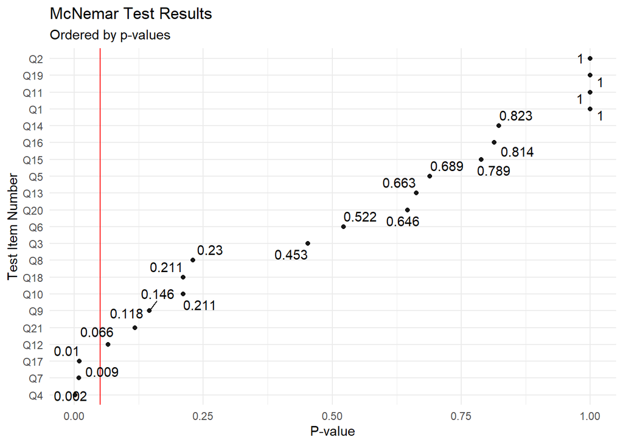

## Indepent Samples Data Analysis Function: “independentsamples()”

Ideally, it requires both pre-test and post-test data to examine the difference between the treatment and the control group (use onewayancova() function if you have all four datasets). However, it is often difficult to get the pre-test data. If that is the case, you can use this function to examine the difference between two (treatment vs. control) groups. Please make sure to name data files accurately (i.e., “data_treat_post.csv” and “data_ctrl_post.csv”) and have them saved in the working directory.

```r
# You can copy and past the following function in the console panel of RStudio: independentsamples()
```

This function automatically cleans the datasets (e.g., converting missing values to “0), binds treatment-control group datasets, runs the Independent Samples T-test (parametric) and Mann–Whitney U test (nonparametric), and then exports outputs to help you examine the difference between the groups. The outputs from this function are as follows.

First, a summary of treatment/control groups’ descriptive statistics will be presented in the R console (and exported to a text file named “independentsamples_outputs”)

```
## # A tibble: 2 × 5
##   datagroup variable           n  mean    sd
##   <fct>     <chr>          <dbl> <dbl> <dbl>
## 1 Control   avg_score_post    54 0.588 0.107
## 2 Treatment avg_score_post    45 0.655 0.111
```

Then, boxplots will be presented in the ‘Plots’ panel in RStudio (and also exported to an image file named “independentsamples_boxplots”) to help you visually inspect the descriptive statistics.

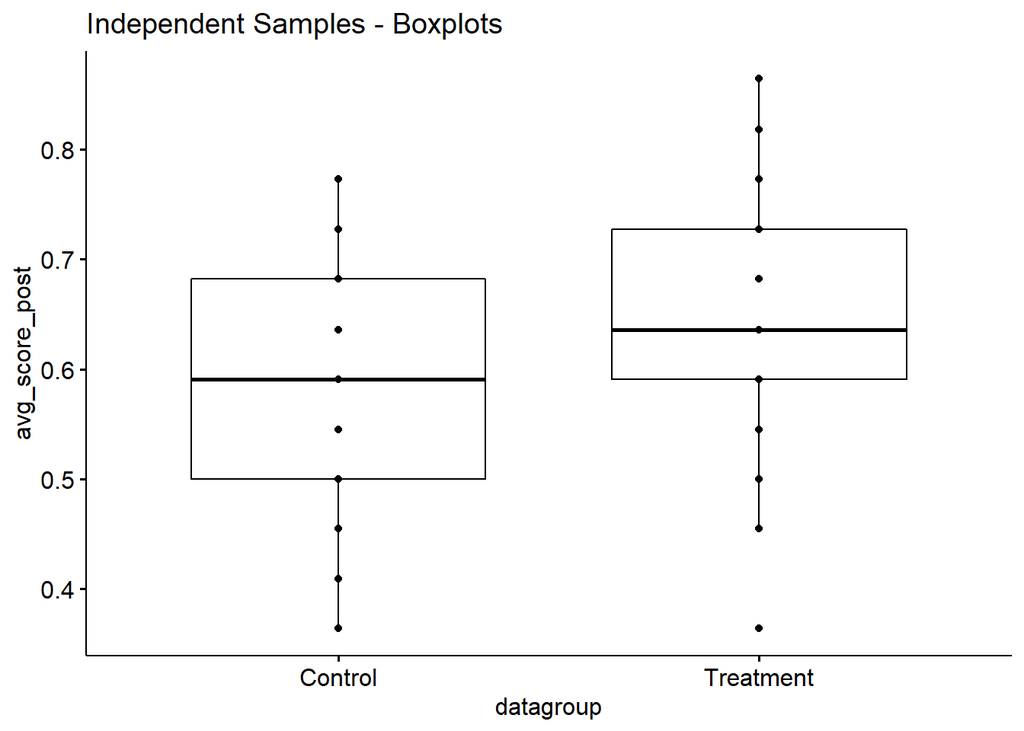

Second, the function run scripts to check the assumptions to be satisfied for using the independent samples t-test (parametric) and present the results in the R console (and exports the results to the working directory (i.e., no outliers, normality for each gruop). You will have the result of the Shapiro-Wilk normality test in your R console (followed by a brief interpretation of the result: e.g., “Interpretation: the assumption of normality has been met (p>0.05 for each group)), as shown below.

```
## # A tibble: 2 × 4
##   datagroup variable       statistic     p
##   <fct>     <chr>              <dbl> <dbl>
## 1 Control   avg_score_post     0.965 0.118
## 2 Treatment avg_score_post     0.970 0.288
```

[output not shown]

If the sample size is greater than 50, it would be better refer to the normal Q-Q plot displayed in the ‘Plots’ panel (exported to an image file named “independentsamples_qqplots”) to visually inspect the normality. This is because the Shapiro-Wilk test becomes very sensitive to a minor deviation from normality at a larger sample size.

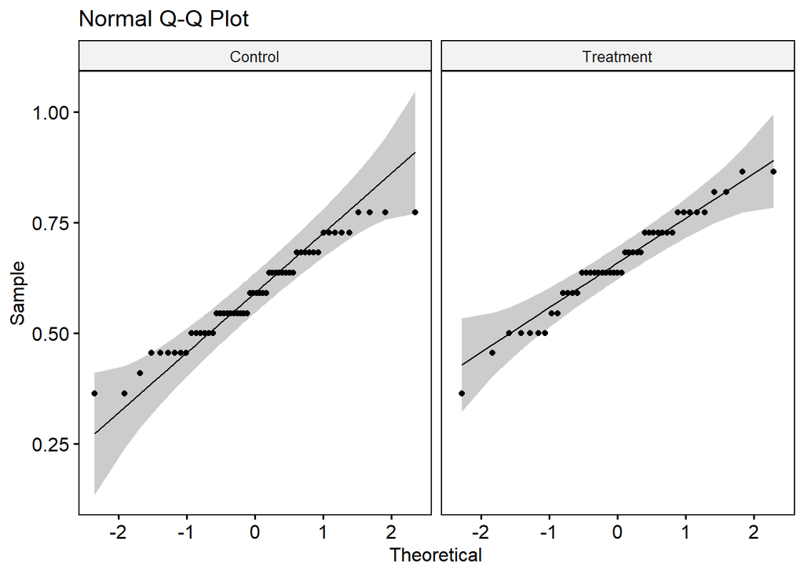

Then, the function proceeds to check the assumption of equal variances between two independent groups and shows the test results with an interpretation of the result, as shown below.

```
## # A tibble: 1 × 4
##     df1   df2 statistic     p
##   <int> <int>     <dbl> <dbl>
## 1     1    97    0.0344 0.853
```

```
## ## Interpretation: the assumption of equality of variances has been met (p>0.05)
```

```
##
##  Welch Two Sample t-test
##
## data:  group_data_binded$avg_score_post by group_data_binded$datagroup
## t = -3.0493, df = 92.636, p-value = 0.002991
## alternative hypothesis: true difference in means between group Control and group Treatment is not equal to 0
## 95 percent confidence interval:
##  -0.11089206 -0.02341905
## sample estimates:
##   mean in group Control mean in group Treatment
##               0.5883333               0.6554889
```

Fourth, if either the sample size is too small (e.g., less than 15) or the data fails to satisfy the normality assumption, then the function further runs scripts for the Mann-Whitney U test (a non-parametric version of the independent samples t-test) and presents its results in the R console (and exports them to the output text file as well), as shown below (Note: you won’t be able to see the non-parametric test result if the data satisfies the normality assumption since the parametric test is more powerful than its non-parametric alternative).

```
##
##  Wilcoxon rank sum test with continuity correction
##
## data:  group_data_binded$avg_score_post by group_data_binded$datagroup
## W = 807.5, p-value = 0.003946
## alternative hypothesis: true location shift is not equal to 0
```

## One-way ANCOVA Function: “onewayancova()”

The function “onewayancova()” is to conduct a one-way analysis of covariance (ANCOVA). The ANCOVA is an extension of the one-way ANOVA to incorporate a covariate variable into the analytic model. The inclusion of this covariate (pre-test scores in this function), which is linearly related to the dependent variable (e.g., post-test scores), into the analysis increases the ability to detect differences between groups of an independent variable (treatment vs. control group in this function). This function automatically merges pre-post datasets, binds treatment-control datasets, and runs scripts to check assumptions of one-way ANCOVA, runs the main One-way ANCOVA, and then exports all outputs for you all at once. Please make sure to name data files accurately (i.e., “data_treat_pre.csv”, “data_treat_post.csv”, “data_ctrl_pre.csv”,” data_ctrl_post.csv”) and have them saved in the working directory. The outputs from this function are as follows.

```r
# You can copy and past the following function in the console panel of RStudio: onewayancova()
```

First, the function presents descriptive statistics and boxplots of all four groups, as shown below.

```
## # A tibble: 2 × 5
##   datagroup  mean     sd   min   max
##   <fct>     <dbl>  <dbl> <dbl> <dbl>
## 1 Control   0.567 0.100  0.318 0.727
## 2 Treatment 0.572 0.0971 0.364 0.773
```

```
## # A tibble: 2 × 5
##   datagroup  mean    sd   min   max
##   <fct>     <dbl> <dbl> <dbl> <dbl>
## 1 Control   0.592 0.107 0.364 0.773
## 2 Treatment 0.655 0.111 0.364 0.864
```

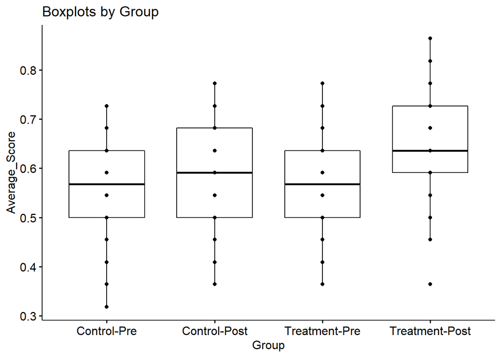

Second, the function runs scripts to check all assumptions to be satisfied and presents the results for you to confidently interpret the results of one-way ANCOVA. The first assumption checked and presented is linearity; the plot below can be used to check the linearity. If you are seeing a liner relationship between the covariate (i.e., pre-test scores for this analysis) and dependent variable (i.e., post-test scores for this analysis) for both treatment and control group in the plot, then you can say this assumption has been met.

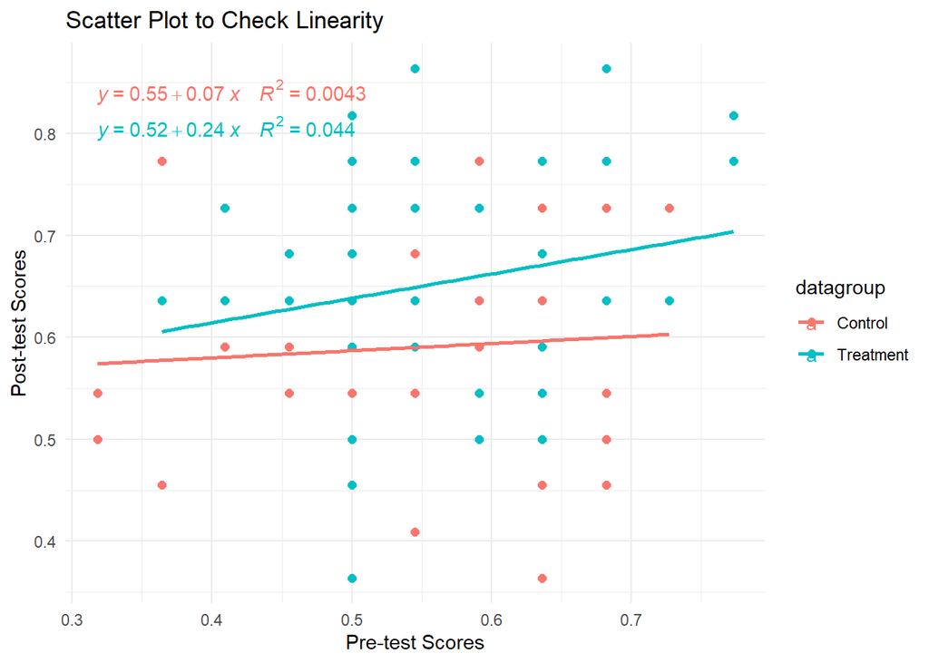

[output not shown]

Then, the assumption of normality of residuals is checked, and its result (with an interpretation) is presented, as shown below.

```
## # Normality of Residuals:
```

```
##
##  Shapiro-Wilk normality test
##
## data:  norm.all.aov$residuals
## W = 0.98491, p-value = 0.3332
```

```
## ## Interpretation: the assumption of normality by group has been met (p>0.05).
```

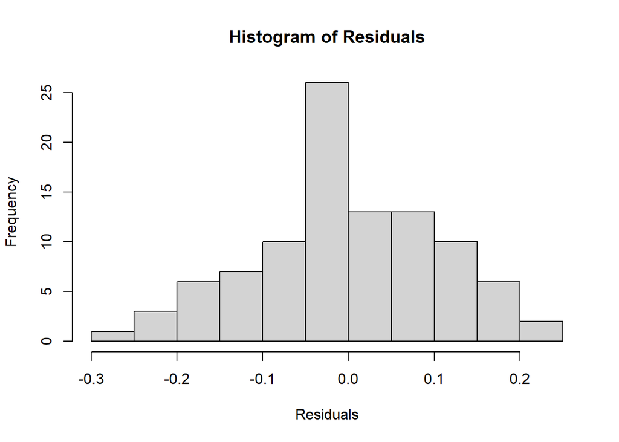

You need to visually examine the histogram (above) and normal Q-Q plot (below) as well to confirm the Shapiro-Wilk normality test result, especially when the sample size is large because the Shapiro-Wilk test becomes very sensitive to a minor deviation from normality at a larger sample size.

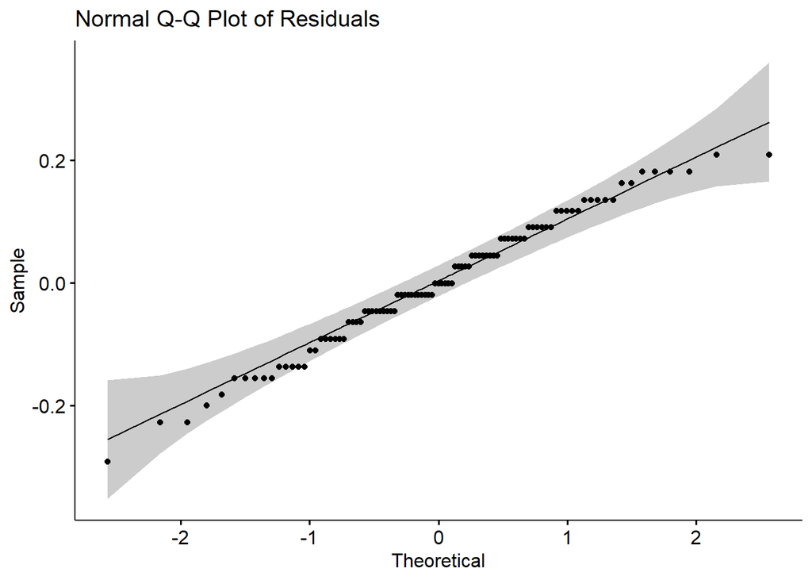

Then, the outputs present the result of checking homogeneity of variance. The function runs Levene Test and reports its result with an interpretation, as shown below.

```
## Levene's Test for Homogeneity of Variance (center = median)
##       Df F value Pr(>F)
## group  1  0.0307 0.8613
##       95
```

```
## ## Interpretation: the assumption of equality of error variances has been met (p>0.05).
```

Then, the function checks the data to see if any outlier exists and reports variables if an outlier is found, as shown below.

```
## [1] avg_score_post avg_score_pre  datagroup      .resid         .cooksd
## [6] .std.resid
## <0 rows> (or 0-length row.names)
```

```
## # Outliers: No outlier has been found.
```

Then, the last assumption of homogeneity of regression line slopes is check, and its results (with an interpretation) are reported, as show below.

```
##
## Call:
## lm(formula = avg_score_post ~ avg_score_pre + datagroup + avg_score_pre:datagroup,
##     data = full_data_binded)
##
## Residuals:
##       Min        1Q    Median        3Q       Max
## -0.274339 -0.074246  0.007143  0.085445  0.214892
##
## Coefficients:
##                                  Estimate Std. Error t value Pr(>|t|)
## (Intercept)                       0.55194    0.08774   6.290 1.02e-08 ***
## avg_score_pre                     0.07016    0.15238   0.460    0.646
## datagroupTreatment               -0.03324    0.13148  -0.253    0.801
## avg_score_pre:datagroupTreatment  0.16914    0.22750   0.743    0.459
## ---
## Signif. codes:  0 '***' 0.001 '**' 0.01 '*' 0.05 '.' 0.1 ' ' 1
##
## Residual standard error: 0.1088 on 93 degrees of freedom
## Multiple R-squared:  0.1014, Adjusted R-squared:  0.07246
## F-statistic:   3.5 on 3 and 93 DF,  p-value: 0.01856
```

```
## ## Interpretation: there was homogeneity of regression slopes as the interaction term (i.e., datagroup:avg_score_pre) was not statistically significant (p>0.05).
```

Third, upon presenting all results of checking the assumptions, the function generates the ANOVA table (type II tests) for you to examine the significance of the group variable.

```
## ANOVA Table (type II tests)
##
##          Effect DFn DFd     F     p p<.05   ges
## 1     datagroup   1  94 8.148 0.005     * 0.080
## 2 avg_score_pre   1  94 1.674 0.199       0.017
```

The function runs a post-hoc analysis to generate estimated (or adjusted) marginal means to compare between the groups and displays/exports a summary statement of the outputs (see the results below).

```
##   avg_score_pre datagroup    emmean         se df  conf.low conf.high
## 1     0.5692887   Control 0.5920313 0.01505694 94 0.5621354 0.6219272
## 2     0.5692887 Treatment 0.6551416 0.01618602 94 0.6230039 0.6872793
##         method
## 1 Emmeans test
## 2 Emmeans test
```

[output not shown]

## One-way Repeated Measures ANOVA Function: “onewayrepeatedanova()”

This function can be used when you collect data from the same students repeatedly at three different time points (e.g., pre-test, post-test, and second post-test) and you want to examine the significance of the changes over time. The function automatically merges pre, post, and post2 datasets, runs the One-way repeated measures ANOVA with assumptions check, and then displays/exports outputs for you all at once. You need to name data files accurately (i.e., “data_treat_pre.csv”, “data_treat_post.csv”, and “data_treat_post2.csv”) and have them saved in the working directory. The outputs/results from this function are as follows.

```r
# You can copy and past the following function in the console panel of RStudio: onewayrepeatedanova()
```

First, the function presents descriptive statistics and boxplots of all three datasets, as shown below.

```
## # A tibble: 3 × 11
##   Time  variable     n   min   max median   iqr  mean    sd    se    ci
##   <fct> <chr>    <dbl> <dbl> <dbl>  <dbl> <dbl> <dbl> <dbl> <dbl> <dbl>
## 1 Pre   Score       45 0.364 0.773  0.545 0.136 0.572 0.097 0.014 0.029
## 2 Post1 Score       45 0.364 0.864  0.636 0.136 0.655 0.111 0.017 0.033
## 3 Post2 Score       45 0.409 0.909  0.682 0.137 0.694 0.121 0.018 0.036
```

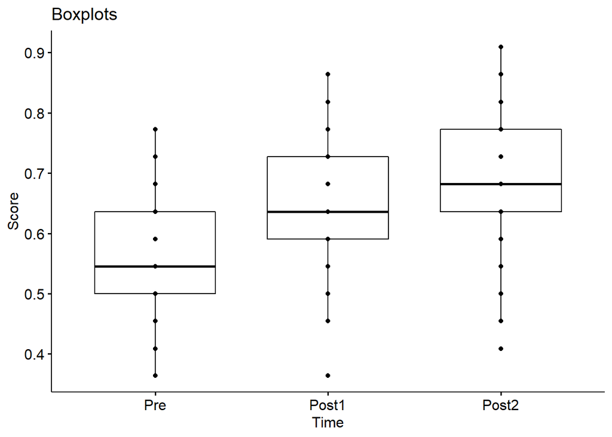

Second, the function runs scripts to check all assumptions to be satisfied and presents the results for you to confidently interpret the results of one-way repeated measures ANOVA. The first assumption checked is no outliers; the result is presented along with an interpretation, as shown below.

```
## ## Interpretation: No extreme outlier was identified in your data.
```

Then, the assumption of normality of residuals is checked, and its result (with an interpretation) is presented, as shown below.

```
##
##  Shapiro-Wilk normality test
##
## data:  resid(res.aov)
## W = 0.98398, p-value = 0.1148
```

```
## --> Interpretation: the residuals were normally distributed (p>0.05).
```

You need to visually examine the histogram and normal Q-Q plot as well to confirm the Shapiro-Wilk normality test result, especially when the sample size is large (e.g., greater than 50) because the Shapiro-Wilk test becomes very sensitive to a minor deviation from normality at a larger sample size.

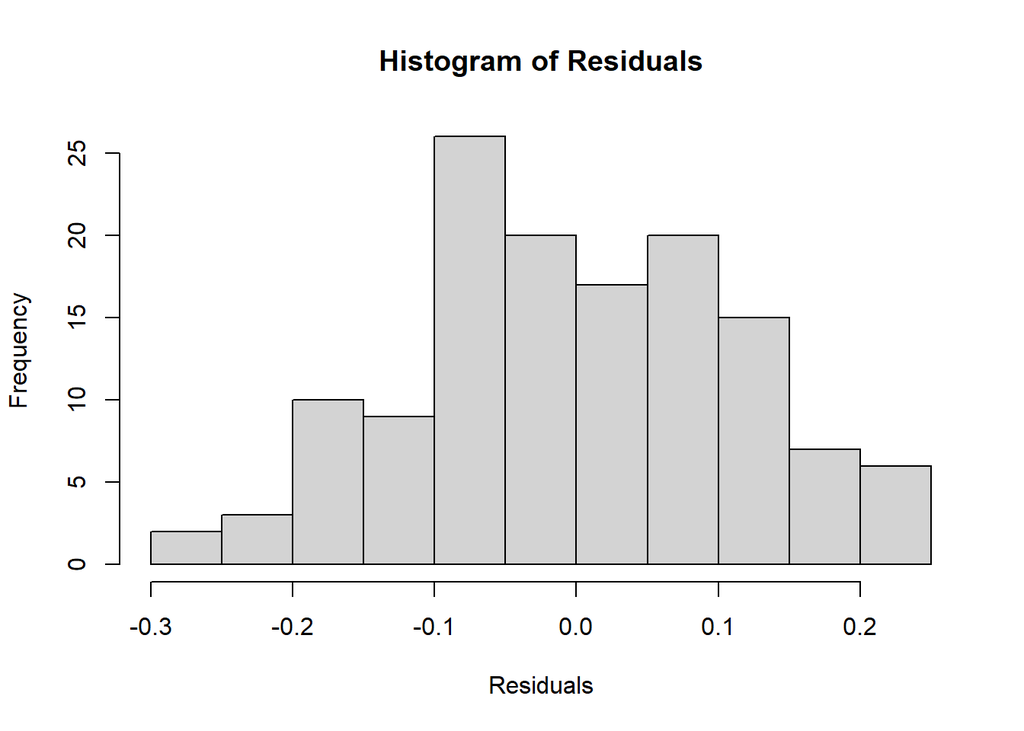

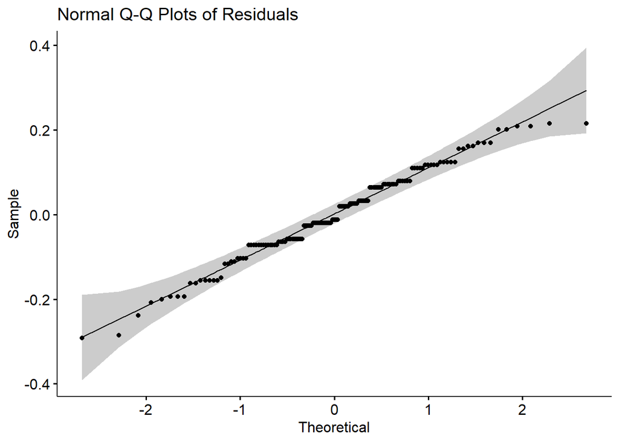

```
## --> Interpretation: if all the points fall in the plots above approximately along the reference line, you can assume normality.
```

Third, the function runs the one-way repeated measures ANOVA and presents its results, as shown below. The assumption of sphericity is checked as part of the computation of this ANOVA test. The Mauchly’s test has been internally run to assess the sphericity assumption. Then, the Greenhouse-Geisser sphericity correction has been automatically applied to factors violating the sphericity of assumption.

```
## ANOVA Table (type III tests)
##
##   Effect  DFn   DFd      F        p p<.05  ges
## 1   Time 1.21 53.06 24.968 1.77e-06     * 0.18
```

```
## --> Interpretation: The average test score at different time points of the intervention are  statistically different: F(1.21 53.06)=24.968, p<0.001, eta2(g)=0.18.
```

Then, if the result above turns out to be significant, then the function proceeds to conduct pairwise comparisons and present the results with an interpretation, as shown below.

```
## # A tibble: 3 × 10
##   .y.   group1 group2    n1    n2 statistic    df         p     p.adj p.adj.si…¹
## * <chr> <chr>  <chr>  <int> <int>     <dbl> <dbl>     <dbl>     <dbl> <chr>
## 1 Score Pre    Post1     45    45     -4.29    44 0.0000963 0.000289  ***
## 2 Score Pre    Post2     45    45     -5.52    44 0.0000017 0.0000051 ****
## 3 Score Post1  Post2     45    45     -4.70    44 0.000026  0.000078  ****
## # … with abbreviated variable name ¹p.adj.signif
```

```
## --> Interpretation for 1: The average pre-test score (0.572) and the average post-test score (0.655) are significantly different. The average post-test score is significantly greater than the average pre-test score (p.adj<0.001).
```

```
## --> Interpretation for 2: The average post1-test score (0.655) and the average post2-test score (0.694) are significantly different. The average post2-test score is significantly greater than the average post-test score (p.adj<0.001).
```

```
## --> Interpretation for 3: The average pre-test score (0.572) and the average post2-test score (0.694) are significantly different. The average post2-test score is significantly greater than the average pre-test score (p.adj<0.001).
```

Fourth, if the normality assumption is violated, the function continues to run the Friedman test, which is the non-parametric version of the parametric one-way repeated measures ANOVA. Although the one-way repeated measures ANOVA is known to be robust to a slight violation of the normality, you may want/need to refer to the result from the non-parametric Friedman test. (The following is just an illuatration of what you will see when the normality assumption is violated; that is, you won’t see this from testing the function with the provided sample data because it satisfies the assumption.)

```
##
##  Friedman rank sum test
##
## data:  avg_score_df
## Friedman chi-squared = 22.419, df = 2, p-value = 1.355e-05
```

```
## --> Interpretation: the median test score is significantly different at the different time points during the intervention (p<0.001).
```

Then, the result of pairwise comparisons with the non-normal data is presented with an interpretation.

```
## # A tibble: 3 × 9
##   .y.   group1 group2    n1    n2 statistic         p     p.adj p.adj.signif
## * <chr> <chr>  <chr>  <int> <int>     <dbl>     <dbl>     <dbl> <chr>
## 1 Score Pre    Post1     45    45      146. 0.000233  0.000699  ***
## 2 Score Pre    Post2     45    45      113  0.0000138 0.0000414 ****
## 3 Score Post1  Post2     45    45        0  0.0000919 0.000276  ***
```

```
## --> Interpretation for 1: the median pre-test score (0.545) and the median post-test score (0.636) are significantly different. The median post-test score is significantly greater than the median pre-test score (p.adj<0.001).
```

```
## --> Interpretation for 2: the median post-test score (0.636) and the median post2-test score (0.682) are significantly different. The median post2-test score is significantly greater than the median post-test score (p.adj<0.001).
```

```
## --> Interpretation for 3: the median pre-test score (0.545) and the median post2-test score (0.682) are significantly different. The median post2-test score is significantly greater than the median pre-test score (p.adj<0.001).
```

## Analysis of Demographic Group Differences Function: “demogroupdiff(csv_data)”

The ‘demogroupdiff()’ function requires users to type a data file name as shown in the sample code below. You can input any of the data file names (i.e., “data_treat_pre.csv”, “data_treat_post.csv”) as they become available for the analysis of demographic group differences. This function automatically combines demographic variables to a dataset, runs the analysis of variance (ANOVA) with assumptions check to examine demographic sub-group differences, and then exports outputs for you all at once. You should have both test data (“data_treat_pre.csv” or “data_treat_post.csv”) and demographic data (“demographic_data.csv”) files in the working directory; please make sure to name data files accurately and have them saved in the working directory.

```r
# You can copy and paste the following function into the console panel of RStudio: demogroupdiff("data_treat_pre.csv") or demogroupdiff("data_treat_post.csv")
```

In addition to the criteria to handle skipped answers (i.e., missing values), this function further asks you to choose a demographic variable to analyze. You will see the demographic group variable names with a numeric code assigned (e.g., gender=1, grade=2). When asked “Enter the number assigned to the demographic variable name you want to analyze,” put the number in the R console and hit the ‘Enter’ key. The function runs all scripts at the back-end and presents/exports the results automatically. The results from this function are as follows.

First, the function presents a summary statistics for each demographic sub-group along with boxplots, as shown below.

```
## # A tibble: 4 × 5
##   group     variable          n  mean    sd
##   <chr>     <chr>         <dbl> <dbl> <dbl>
## 1 Freshman  average_score    11 0.562 0.091
## 2 Junior    average_score    14 0.594 0.103
## 3 Senior    average_score    10 0.532 0.113
## 4 Sophomore average_score    15 0.573 0.087
```

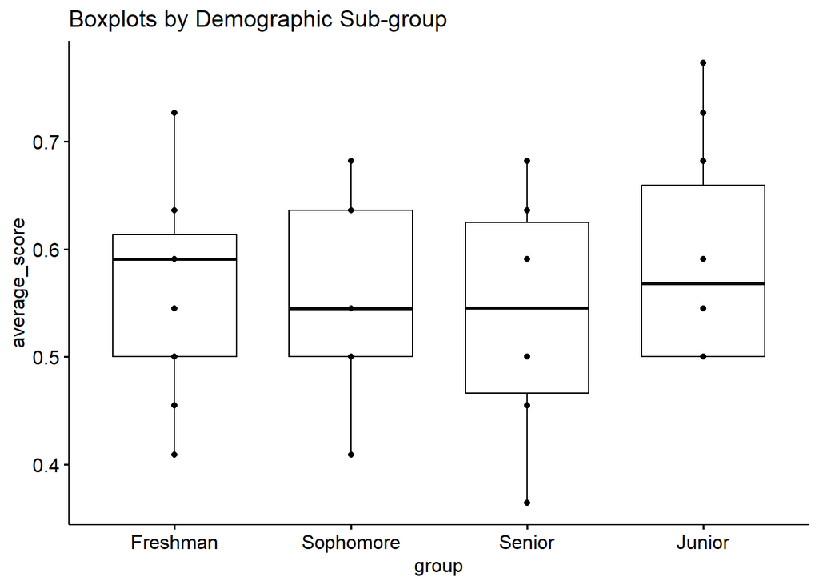

Second, the function continues to test the assumptions for the parametric one-way ANOVA. The first assumption checked is the normality of residuals; the Shapiro-Wilk test is performed, and its result is presented with an interpretation, as shown below.

```
##
##  Shapiro-Wilk normality test
##
## data:  resid(one_way)
## W = 0.96075, p-value = 0.09553
```

```
## ## Interpretation: the assumption of normality by group has been met (p>0.05).
```

If the sample size is greater than 50, it would be better refer to the normal Q-Q plot displayed in the ‘Plots’ panel (exported to an image file named “demogroupdiff_qqplots”) to visually inspect the normality. This is because the Shapiro-Wilk test becomes very sensitive to a minor deviation from normality at a larger sample size. The plot is presented below with a guidance for interpretation.

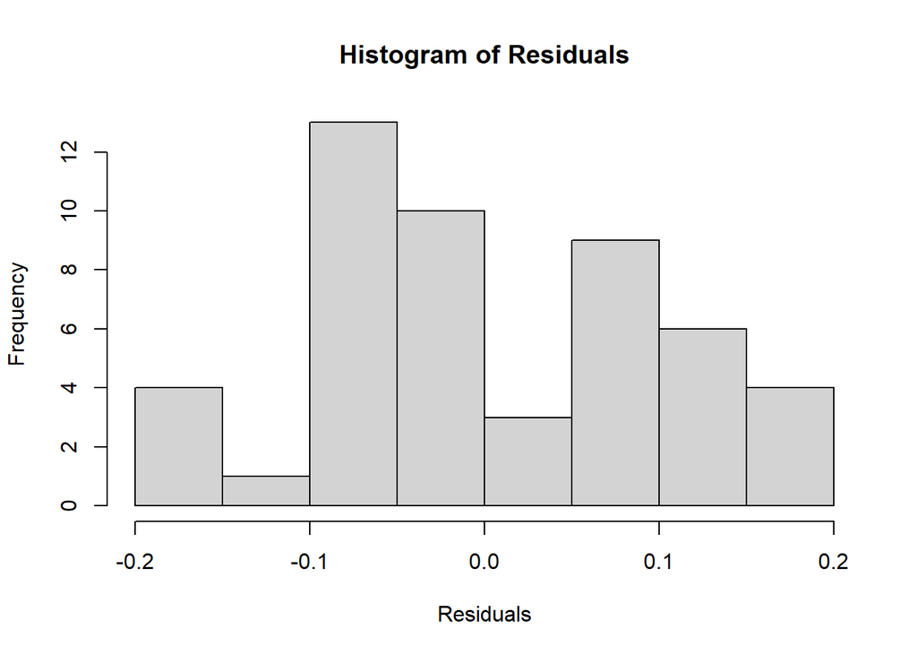

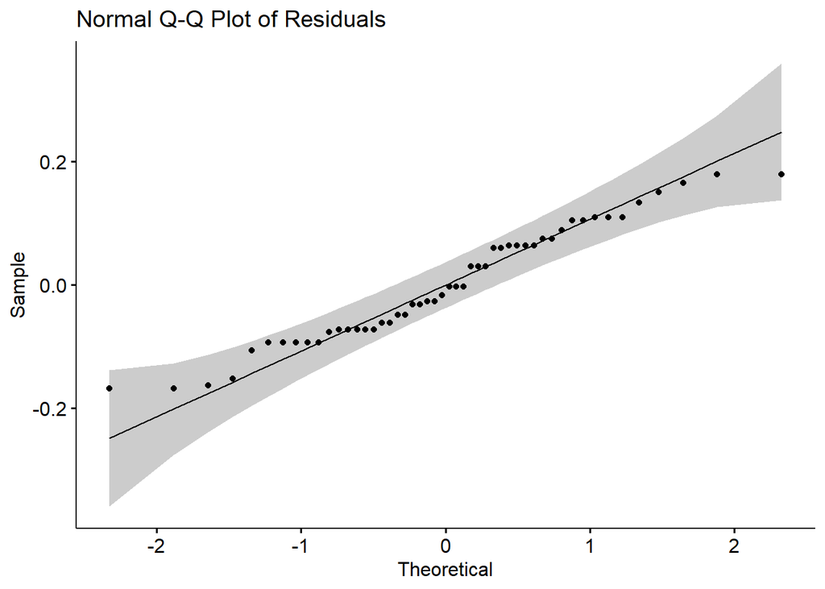

```
## --> Interpretation: if all the points fall in the plots above approximately along the reference line, you can assume normality.
```

The second assumption checked is homogeneity of variance. The result is presented with an interpretation and a visual representation, as shown below.

```
## Levene's Test for Homogeneity of Variance (center = median)
##       Df F value Pr(>F)
## group  3   0.371 0.7743
##       46
```

```
## ## Interpretation: the assumption of equality of variances has been met (p>0.05).
```

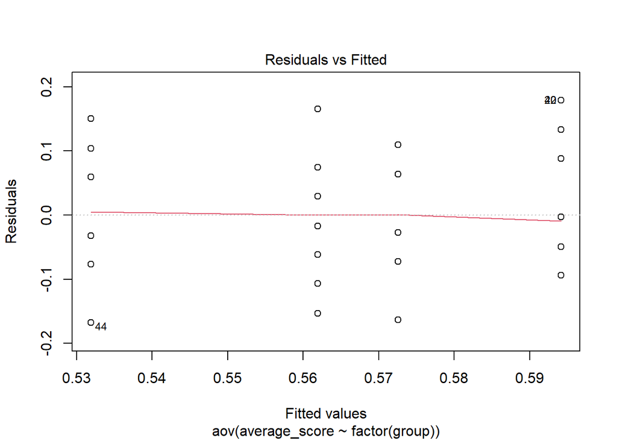

Third, upon presenting the results of assumption checking, the function proceeds to run the one-way ANOVA with equal variances ‘assumed’ or ‘not assumed’ depending on the result of testing homegeneity of variance above. Then, the result with an interpretation is provided, as shown below.

```
## Results of One-way ANOVA: Group Difference(s) (Parametric: Equal variances assumed)
##               Df Sum Sq  Mean Sq F value Pr(>F)
## factor(group)  3 0.0233 0.007775   0.805  0.497
## Residuals     46 0.4442 0.009657
## --> Interpretation: the difference among the demographic sub-groups is not significant (P>0.05).
## Pairwide Comparisons (Equal variances assumed)
```

Then, the function runs scripts to conduct pairwise comparisons and presents the result, as shown below.

```
## Pairwide Comparisons (Equal variances assumed)
##   Tukey multiple comparisons of means
##     95% family-wise confidence level
##
## Fit: aov(formula = average_score ~ factor(group), data = data_original)
##
## $`factor(group)`
##                           diff         lwr        upr     p adj
## Junior-Freshman     0.03223377 -0.07330199 0.13776952 0.8474823
## Senior-Freshman    -0.03000909 -0.14445579 0.08443761 0.8969661
## Sophomore-Freshman  0.01069091 -0.09328546 0.11466728 0.9927074
## Senior-Junior      -0.06224286 -0.17069336 0.04620765 0.4284339
## Sophomore-Junior   -0.02154286 -0.11888016 0.07579445 0.9346245
## Sophomore-Senior    0.04070000 -0.06623364 0.14763364 0.7418160
```

Fourth, in case the normality assumption is violated, the function continues to run the Kruskal-Wallis test, which is the non-parametric version of the parametric one-way ANOVA. Although ANOVA is known to be robust to a slight violation of the normality, you may want/need to refer to the result from the non-parametric Kruskal-Wallis test. (The following is just an illuatration of what you will see when the normality assumption is violated; that is, you won’t see this from testing the function with the provided sample data because it satisfies the assumption.)

```
## Results of Kruskal_Wallis Test (Non-parametric)
```

```
##
##  Kruskal-Wallis rank sum test
##
## data:  average_score by group
## Kruskal-Wallis chi-squared = 1.412, df = 3, p-value = 0.7027
```

```
## Interpretation: The difference among demographic sub-groups is not significant (p>0.05).
```

```
##
##  Pairwise comparisons using Wilcoxon rank sum test with continuity correction
##
## data:  data_original$average_score and data_original$group
##
##           Freshman Junior Senior
## Junior    0.7      -      -
## Senior    0.7      0.7    -
## Sophomore 0.7      0.7    0.7
##
## P value adjustment method: BH
```

# DBERlibR: Automated Assessment Data Analysis

HelikarLab

6/30/2022

This is a documentation of DBERlibR, which represents Discipline-based Education Research library R. The package runs R scripts to clean the data, merge/bind multiple datasets (as necessary), check assumption(s) for a specific statistical technique (as necessary), run the main assessment data analysis, and export the analysis output(s) all at once. The output(s) contain(s) a sample interpretation of the results for the convenience of users. Users need to prepare the data file as instructed, save it in the folder designated as a working directory in RStudio, load all dependencies, and type a function in the R console to conduct a specific data analysis.

## Package Installation

The “DBERlibR” package is currently published on GitHub, so you need to follow the steps to install a package from GitHub, as instructed below. Please make sure to have the newest version of R (https://cloud.r-project.org/) and the most recent RStudio (https://www.rstudio.com/products/rstudio/download/) installed on your machine before proceeding.

1. First, you need to install the “devtools” package in your RStudio if you haven’t done so yet. Refer to the instructions for installing devtools, available at https://www.r-project.org/nosvn/pandoc/devtools.html. You can do this from CRAN; just copy/type the line below in your R console and hit the Enter key.

```r
install.packages("devtools", repos="http://cran.us.r-project.org")
```

2. You need to have a working development environment before loading the package “devtools” in RStudio. Please follow Step 2 in the instruction on devtools linked above. For example, you need to download and install RTools if the operating system of your machine is Windows; follow the instruction available https://cran.r-project.org/bin/windows/Rtools/rtools40.html (You may want to refer to a YouTube video on how to install RTools40: e.g., https://www.youtube.com/watch?v=njZBf34Akgo).
3. Once you have a working development environment, load the “devtools” package in RStudio; just copy/type the line below in your R console and hit the Enter key.

```r
library(devtools)
```

4. Now you’re ready to install the package “DBERlibR” from GitHub. In most cases, you just use install_github(“author/package”). So, you can just copy/type the line below in your R console and hit the Enter key.

```r
install_github("HelikarLab/DBERlibR", repos="http://cran.us.r-project.org")
```

If you get the question, “Do you want to install from sources the package which needs compilation?”, this often means that the package has been updated recently on CRAN but the binary isn’t yet available for your OS (can take a day or two). There are probably other scenarios when the binary isn’t available for your platform. If you say no, you won’t get the most recent version. But this might be just fine unless you were specifically installing because of an update. If you say yes, the package will be built from source locally. If it has compiled code and you’ve never set up build tools for R, then this won’t actually succeed.

If you fail to install the package due to an error related to the package of “rlang,” you need to first remove it (run remove.packages(“rlang”) in the R console) and then install it again (run install.packages(“rlang”) in the R console). Then try Step 4 again.

## Load DBERlibR, Set Working Directory, and Save Data File(s) in that Directory

Load DBERlibR by typing/copying the line below in the R console and hitting the Enter key.

```r
library(DBERlibR)
```

Then, you need to set “Working Directory” under the “Session” menu in R Studio. The directory should be a folder where (all) data file(s) is(are) saved because the functions in this package import accurately named data file(s) from the working directory. Please download the sample data folder (4 csv files in it) from “https://github.com/HelikarLabPersonal/DBERlibR” to test the package. You need to add a GitZip extension to your browser to download a folder from GitHub (refer to a YouTube video on how to do it: https://www.youtube.com/watch?v=6dnzDILMobU). Once downloaded unzipped, save all 4 csv files in the working directory you’ve set.

## Data Preparation

The data should include only (student) id and questions (no other data like demographic information; you should save other data in a separate file along with id if you have them). The question data should be binary (i.e., 1 for correct answers, 0 for incorrect answers); if your data contains multiple-choice answers, you must transform them into binary data. For your reference, the data file should look like the sample below. The data file should be in the “csv” format.

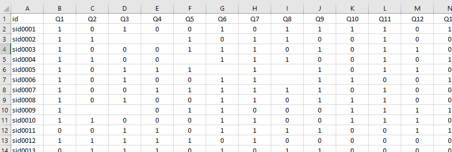

assessment data Format

As you can see in the data table above, the questions were named Q1, Q2, Q3, and so on, but you can name the questions differently; please make sure to use the same question name across different datasets (i.e. treatment group pre-test data, treatment group post-test data, control group pre-test data, and control group post-test data). Blank cells indicate skipped answers; these blank cells will be treated as incorrect in the process of data preparation. Please do not fill the blank cells (i.e., skipped answers) with any simbol (e.g., “NA”, “99”); those simbols will cause an error in data preparation/analysis. An csv data file exported from online survey platform like Qualtrics may contain two header rows (one for question number and another for question wordings); you need to leave only one header with id and question numbers. Please open the sample data files to see how they are prepared consistently.

You need to save the data file exactly the same as the sample data files (use the same file names): “data_treat_pre.csv” for the treatment group’s pre-test data; “data_treat_post.csv” for the treatment group’s post-test data; “data_ctrl_pre.csv” for the control group’s pre-test data; and “data_ctrl_post.csv” for the control group’s post-test data.

Skipped answers in the data file(s) (i.e., blank cells in the dataframe above) will be treated as incorrect in this package. Too many skipped answers may skew the results of data analysis. Users can exclude students with too many skipped answers by defining too many skipped answers; you can just provide a percentage as a response to the following prompt (You need to respond to this prompt whenever you run a function in this package):

```
## [1] "Please enter a percentage (e.g., 10%, 25%): "
```

If you have students’ demographic information and want to examine the differences of demographic subgroups (e.g., male vs. female), you should save other data in a separate file along with id (the same id as in the assessment data file(s)). Although The data format should look like the one below. Please DO NOT convert the subgroup label to a numeric code; it will be hard to read the results if you use a numeric code.

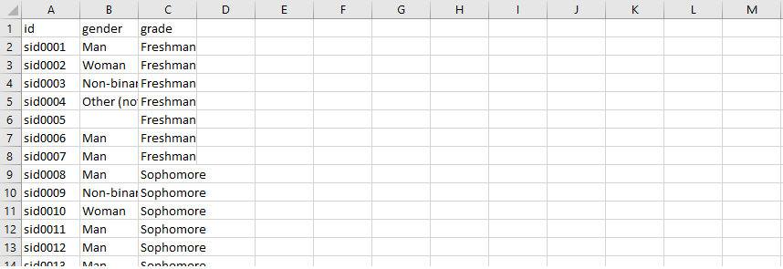

Demographic Data Format

## Item Analysis Function: “itemanalysis()”

The item analysis function requires users to type a data file name as shown in the sample code below. You can input any of the data file names (i.e., “data_treat_pre.csv”, “data_treat_post.csv”, “data_ctrl_pre.csv”, or “data_ctrl_post.csv”) as they become available for item analysis.

```r
# You can copy and paste the following function into the console panel of RStudio: itemanalysis("data_treat_pre.csv"), itemanalysis("data_ctrl_pre.csv"), itemanalysis("data_treat_post.csv"), or itemanalysis("data_ctrl_pre.csv")
```

The function will display a message and prompt to determine ‘students with too many skipped answers’ to be excluded from data analysis. Once you respond to this prompt (i.e., either provide an alternative rate or just hit the Enter key), the function automatically reads and cleans the data (e.g., deleting students with too many skipped answers, converting missing values to “0”), calculates difficulty and discriminant scores, displays all results in the Console and Plots panels of RStudio, and exports the results to an Excel file, which is saved in the working directory. The Excel file name follows the data file name used for item analysis; for example, if you’ve input “data_treat_pre.csv” in the function, then the output Excel file name contains “treat_pre.” The function also generates plots in the jpeg file format to visualize the results; the jpeg file name follows the data file name as well so that you can easily find the results of the item analysis you’ve just run.

Item difficulty refers to the proportion of students that correctly answered the item, scaled 0 to 1. Ideal values are known to be slightly higher than midway between a chance to be chosen (i.e., 1 divided by the number of choices) and a perfect score (1) for the item. In common, values below 0.2 are considered to indicate “very difficult” items and need to be reviewed for possible confusing language, removed from the test, and/or identified as an area for re-instruction to improve test instruments. In addition to improving the test instrument, the results of item difficulty analysis inform the areas of weakness in students’ knowledge to be taken into consideration in improving teaching modules. The difficulty plot is shown below.

```
## Item Analysis Results - Difficulty
```

```
##     q.number difficulty_index
## 1         Q1             0.86
## 2         Q2             0.44
## 3         Q3             0.70
## 4         Q4             0.36
## 5         Q5             0.46
## 6         Q6             0.62
## 7         Q7             0.60
## 8         Q8             0.48
## 9         Q9             0.64
## 10       Q10             0.58
## 11       Q11             0.70
## 12       Q12             0.60
## 13       Q13             0.36
## 14       Q14             0.54
## 15       Q15             0.78
## 16       Q16             0.72
## 17       Q17             0.64
## 18       Q18             0.38
## 19       Q19             0.58
## 20       Q20             0.56
## 21       Q21             0.38
## 22       Q22             0.52
## 23 avg_score             0.57
```

```
## The result above has been exported to an Excel file, of which file name includes 'itemanalysis_outputs,' in the working directory.
```

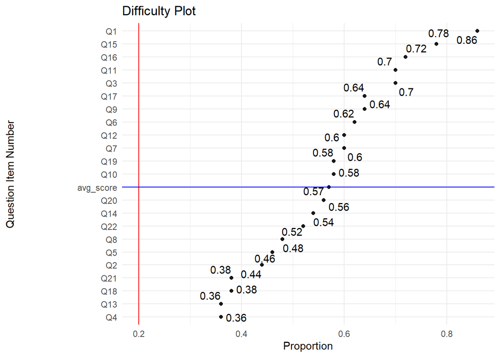

```
## Refer to 'Difficulty Plot' in the 'Plots' panel. The plot has also been exported to an image file, of which file name includes 'itemanalysis_difficulty_plot,' in the working directory.
```

```
## As seen in the difficulty plot, none of the difficulty indixes was found to be lower than 0.2.
```

The proportions in the generated difficulty plot above are ordered by their size, and the plot displays a vertical red-colored line that represents the threshold of 0.2 so that you can instantly find the question items that warrant your attention for improvement. The plot above does not have any item of which proportion size is below 0.2.

Meanwhile, item discrimination represents the relationship between how well students did on the item and their total test performance, ranging from 0 to 1. The closer to 1, the better; the scales of 0.2 or higher are generally known to be acceptable. Items with discrimination values near or less than zero need to be removed from the test. For example, negative values indicate that students who did poorly on the test did better on that item than those who overall did well, which doesn’t make sense. Removing the items highlighted in red, especially with negative values, in the table may need to be considered, or improving instructions related to the items with low values should be considered to increase the values. The discrimination plot is shown below (ignore the R codes below since it’s just to show how the plot is generated; that is, the function automatically runs the codes).

```
## Item Analysis Results - Discrimination:
```

```
##      qnumber discrimination_index
## 1         Q1                -0.12
## 2         Q2                -0.25
## 3         Q3                 0.15
## 4         Q4                 0.08
## 5         Q5                -0.16
## 6         Q6                 0.09
## 7         Q7                 0.08
## 8         Q8                 0.19
## 9         Q9                 0.33
## 10       Q10                 0.14
## 11       Q11                 0.30
## 12       Q12                 0.29
## 13       Q13                 0.53
## 14       Q14                 0.16
## 15       Q15                 0.17
## 16       Q16                 0.48
## 17       Q17                -0.06
## 18       Q18                 0.57
## 19       Q19                 0.31
## 20       Q20                 0.55
## 21       Q21                 0.30
## 22       Q22                 0.28
## 23 avg_score                 1.00
```

```
## The result above has been exported to an Excel file, of which file name includes 'itemanalysis_outputs,' in the working directory.
```

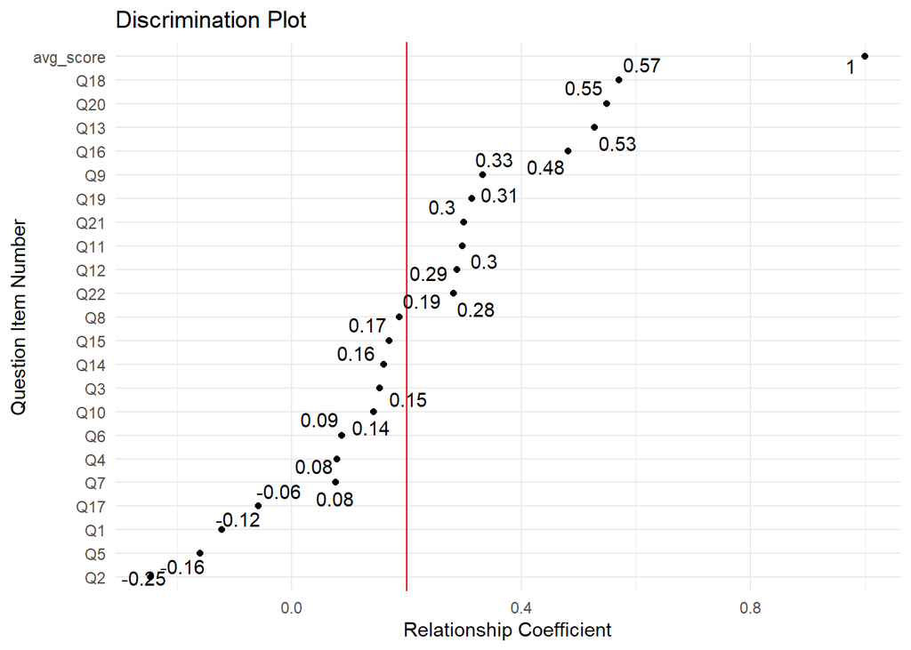

```
## Refer to 'Discrimination Plot' in the 'Plots' panel. The plot has also been exported to an image file, of which file name includes 'itemanalysis_discrimination_plot,' in the working directory.
```

```
## As seen in the discrimination plot, the following question items present a discrimination index lower than 0.2:
##  [1] "Q1"  "Q2"  "Q3"  "Q4"  "Q5"  "Q6"  "Q7"  "Q8"  "Q10" "Q14" "Q15" "Q17"
```

The relationship coefficients in the generated discrimination plot are ordered by their size, and the plot displays a vertical red-colored line that represents the threshold of 0.2 so that you can instantly find the question items that warrant your attention for improvement. The plot above presents 12 question items of which coefficients are less than 0.2.

## Paired Samples Data Analysis Function: “pairedsamples()”

An ideal situation for examining the effect of teaching modules on student performance (i.e., pre-post difference) is to have a control group to compare with the treatment/intervention group (use onewayancova() function if you have all four datasets). However, it is often difficult to get the control group data. If that is the case, you can use this function to examine the difference between pre-test and post-test scores of the treatment group. Please make sure to name data files accurately (i.e., “data_treat_pre.csv”,“data_treat_post.csv”) and have them saved in the working directory.

```r
# You can copy and past the following function in the console panel of RStudio: pairedsamples()
```

The “pairedsamples()” function automatically cleans the datasets (e.g., converting missing values to “0), merges pre-post datasets, runs the Paired Samples T-test (Parametric) and Wilcoxon Signed-Rank test (Nonparametric), and then exports outputs to help you examine the difference between pre-post scores. The outputs of the”pairedsamples()” function are as follows.

First, a summary of pre-/post-test scores’ descriptive statistics will be presented in the R console (and exported to a text file named “pairedsamples_outputs”).

```
## # A tibble: 2 × 11
##   Time  variable     n   min   max median   iqr  mean    sd    se    ci
##   <fct> <chr>    <dbl> <dbl> <dbl>  <dbl> <dbl> <dbl> <dbl> <dbl> <dbl>
## 1 Pre   Score       45 0.364 0.773  0.545 0.136 0.572 0.097 0.014 0.029
## 2 Post  Score       45 0.364 0.864  0.636 0.136 0.655 0.111 0.017 0.033
```

Then, boxplots will be presented in the ‘Plots’ panel in RStudio (and also exported to an image file named “pairedsamples_boxplots”) to help you visually inspect the descriptive statistics.

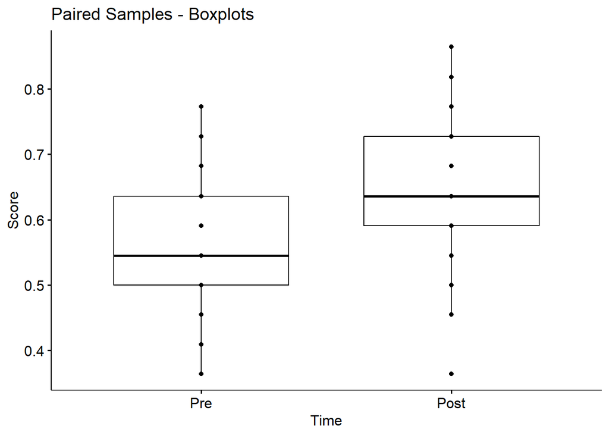

```
## # A tibble: 1 × 3
##   variable statistic      p
##   <chr>        <dbl>  <dbl>
## 1 avg_diff     0.952 0.0607
```

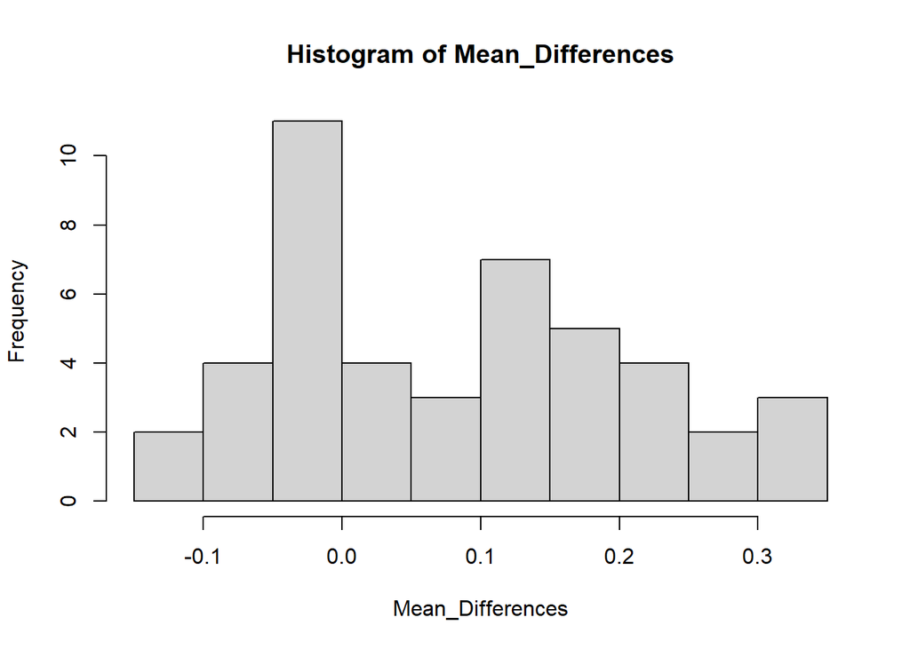

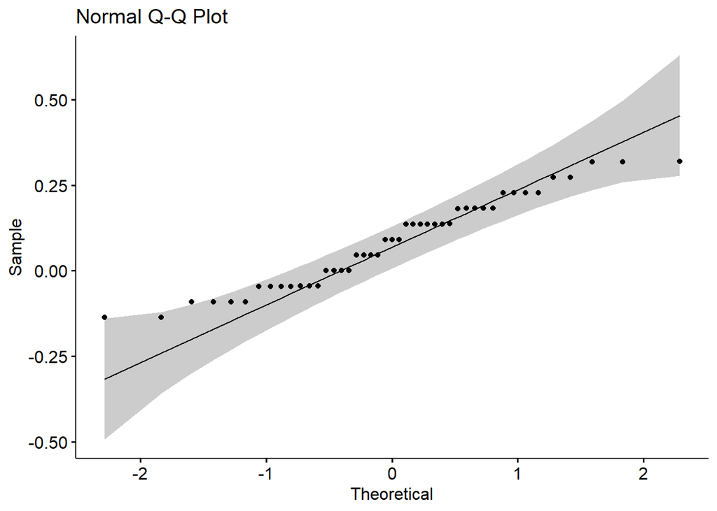

```
##
##  Paired t-test
##
## data:  treat_data_merged$avg_score_pre and treat_data_merged$avg_score_post
## t = -4.2903, df = 44, p-value = 9.625e-05
## alternative hypothesis: true mean difference is not equal to 0
## 95 percent confidence interval:
##  -0.12319734 -0.04444711
## sample estimates:
## mean difference
##     -0.08382222
```

Fourth, if the sample size is considered to be too small (e.g., less than 15), or the data has failed to satisfy the normality assumption for using the parametric paired samples t-test, then the function automatically runs the Wilcoxon signed rank sum test (a non-parametric version of the paired samples t-test) and presents its results in the R console (and exports them to the output text file as well), as shown below (hence, you won’t be able to see the non-parametric test result if you can use the parametric test result, since the parametric test is more powerful than its non-parametric alternative).

```
##
##  Wilcoxon signed rank test with continuity correction
##
## data:  treat_data_merged$avg_score_pre and treat_data_merged$avg_score_post
## V = 146.5, p-value = 0.0002332
## alternative hypothesis: true location shift is not equal to 0
```

Finally, the function further runs scripts to run McNemar test to examine the difference between pre-post scores for individual test items. The information generated from this function is useful in determining which items would have been signficantly impacted by the treatment/intervention (e.g., teaching modules). As shown in the plot below, the function generates a plot to show the size of p-values (significance of the pre-post difference) for individual test items (ordered by the p-values). The plot displays a vertical line to show a threshold of statistical significance (p=0.05), so that you can easily find test question items of which the difference between pre-post scores is statistically significant. A brief summary of the plot is provided in the R console for your convenience: e.g., “the plot shows the statistical significance of the difference between pre-post scores of the test items”Q4,” “Q7,” and “Q17.”

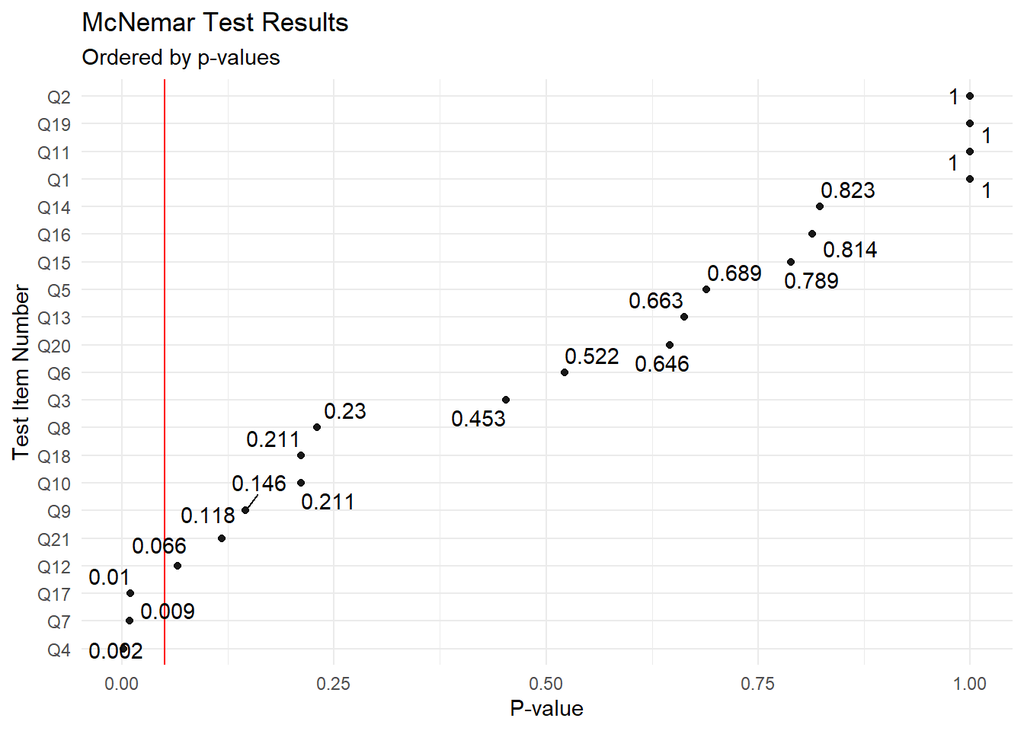

## Indepent Samples Data Analysis Function: “independentsamples()”

Ideally, it requires both pre-test and post-test data to examine the difference between the treatment and the control group (use onewayancova() function if you have all four datasets). However, it is often difficult to get the pre-test data. If that is the case, you can use this function to examine the difference between two (treatment vs. control) groups. Please make sure to name data files accurately (i.e., “data_treat_post.csv” and “data_ctrl_post.csv”) and have them saved in the working directory.

```r
# You can copy and past the following function in the console panel of RStudio: independentsamples()
```

This function automatically cleans the datasets (e.g., converting missing values to “0), binds treatment-control group datasets, runs the Independent Samples T-test (parametric) and Mann–Whitney U test (nonparametric), and then exports outputs to help you examine the difference between the groups. The outputs from this function are as follows.

First, a summary of treatment/control groups’ descriptive statistics will be presented in the R console (and exported to a text file named “independentsamples_outputs”)

```
## # A tibble: 2 × 5
##   datagroup variable           n  mean    sd
##   <fct>     <chr>          <dbl> <dbl> <dbl>
## 1 Control   avg_score_post    54 0.588 0.107
## 2 Treatment avg_score_post    45 0.655 0.111
```

Then, boxplots will be presented in the ‘Plots’ panel in RStudio (and also exported to an image file named “independentsamples_boxplots”) to help you visually inspect the descriptive statistics.

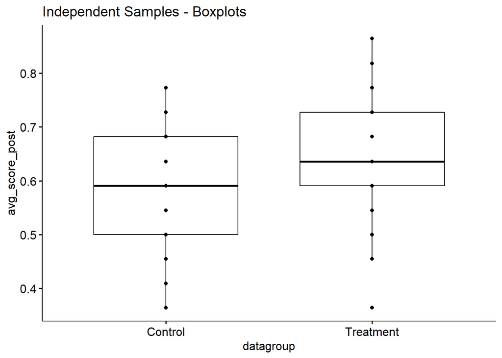

Second, the function run scripts to check the assumptions to be satisfied for using the independent samples t-test (parametric) and present the results in the R console (and exports the results to the working directory (i.e., no outliers, normality for each gruop). You will have the result of the Shapiro-Wilk normality test in your R console (followed by a brief interpretation of the result: e.g., “Interpretation: the assumption of normality has been met (p>0.05 for each group)), as shown below.

```
## # A tibble: 2 × 4
##   datagroup variable       statistic     p
##   <fct>     <chr>              <dbl> <dbl>
## 1 Control   avg_score_post     0.965 0.118
## 2 Treatment avg_score_post     0.970 0.288
```

[output not shown]

If the sample size is greater than 50, it would be better refer to the normal Q-Q plot displayed in the ‘Plots’ panel (exported to an image file named “independentsamples_qqplots”) to visually inspect the normality. This is because the Shapiro-Wilk test becomes very sensitive to a minor deviation from normality at a larger sample size.

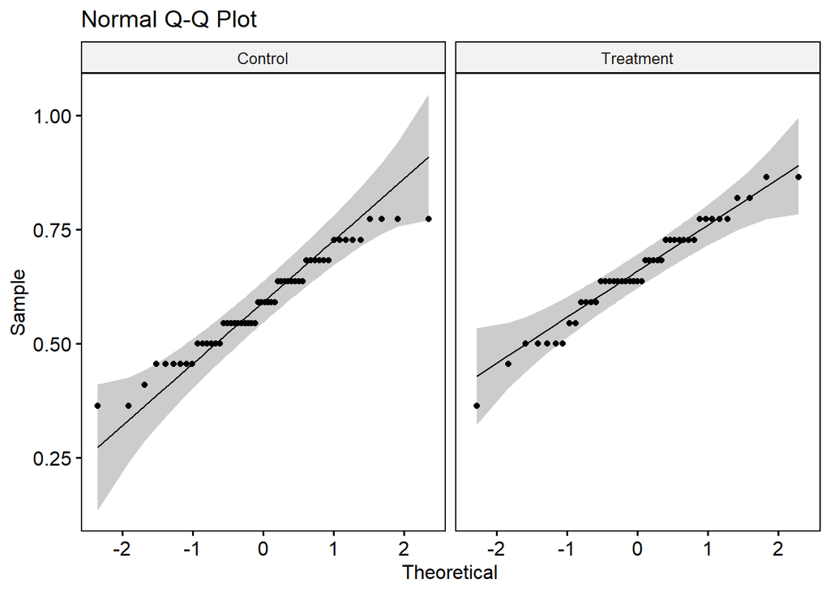

Then, the function proceeds to check the assumption of equal variances between two independent groups and shows the test results with an interpretation of the result, as shown below.

```
## # A tibble: 1 × 4
##     df1   df2 statistic     p
##   <int> <int>     <dbl> <dbl>
## 1     1    97    0.0344 0.853
```

```
## ## Interpretation: the assumption of equality of variances has been met (p>0.05)
```

```
##
##  Welch Two Sample t-test
##
## data:  group_data_binded$avg_score_post by group_data_binded$datagroup
## t = -3.0493, df = 92.636, p-value = 0.002991
## alternative hypothesis: true difference in means between group Control and group Treatment is not equal to 0
## 95 percent confidence interval:
##  -0.11089206 -0.02341905
## sample estimates:
##   mean in group Control mean in group Treatment
##               0.5883333               0.6554889
```

Fourth, if either the sample size is too small (e.g., less than 15) or the data fails to satisfy the normality assumption, then the function further runs scripts for the Mann-Whitney U test (a non-parametric version of the independent samples t-test) and presents its results in the R console (and exports them to the output text file as well), as shown below (Note: you won’t be able to see the non-parametric test result if the data satisfies the normality assumption since the parametric test is more powerful than its non-parametric alternative).

```
##
##  Wilcoxon rank sum test with continuity correction
##
## data:  group_data_binded$avg_score_post by group_data_binded$datagroup
## W = 807.5, p-value = 0.003946
## alternative hypothesis: true location shift is not equal to 0
```

## One-way ANCOVA Function: “onewayancova()”

The function “onewayancova()” is to conduct a one-way analysis of covariance (ANCOVA). The ANCOVA is an extension of the one-way ANOVA to incorporate a covariate variable into the analytic model. The inclusion of this covariate (pre-test scores in this function), which is linearly related to the dependent variable (e.g., post-test scores), into the analysis increases the ability to detect differences between groups of an independent variable (treatment vs. control group in this function). This function automatically merges pre-post datasets, binds treatment-control datasets, and runs scripts to check assumptions of one-way ANCOVA, runs the main One-way ANCOVA, and then exports all outputs for you all at once. Please make sure to name data files accurately (i.e., “data_treat_pre.csv”, “data_treat_post.csv”, “data_ctrl_pre.csv”,” data_ctrl_post.csv”) and have them saved in the working directory. The outputs from this function are as follows.

```r
# You can copy and past the following function in the console panel of RStudio: onewayancova()
```

First, the function presents descriptive statistics and boxplots of all four groups, as shown below.

```
## # A tibble: 2 × 5
##   datagroup  mean     sd   min   max
##   <fct>     <dbl>  <dbl> <dbl> <dbl>
## 1 Control   0.567 0.100  0.318 0.727
## 2 Treatment 0.572 0.0971 0.364 0.773
```

```
## # A tibble: 2 × 5
##   datagroup  mean    sd   min   max
##   <fct>     <dbl> <dbl> <dbl> <dbl>
## 1 Control   0.592 0.107 0.364 0.773
## 2 Treatment 0.655 0.111 0.364 0.864
```

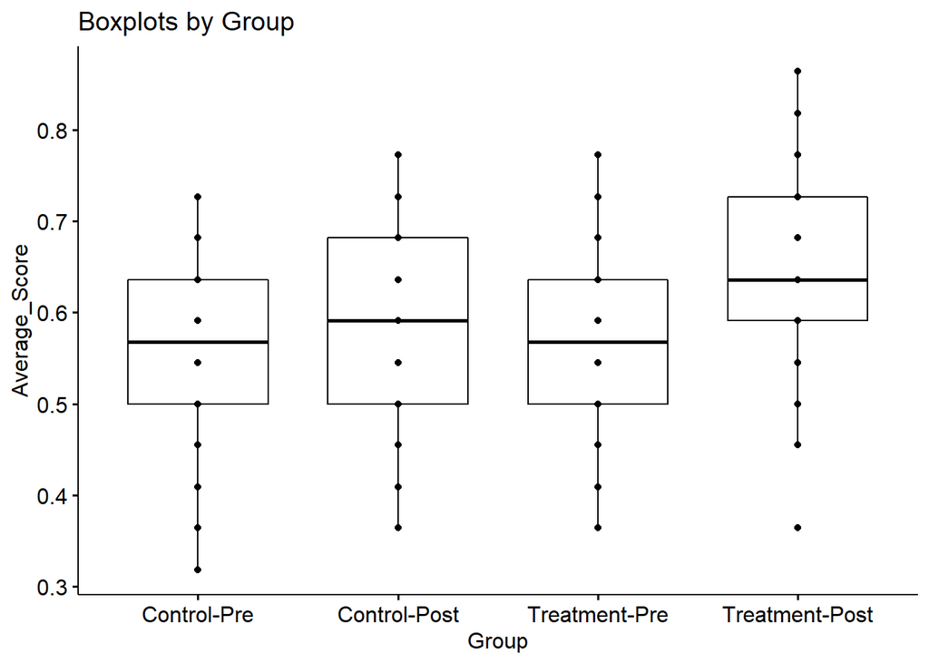

Second, the function runs scripts to check all assumptions to be satisfied and presents the results for you to confidently interpret the results of one-way ANCOVA. The first assumption checked and presented is linearity; the plot below can be used to check the linearity. If you are seeing a liner relationship between the covariate (i.e., pre-test scores for this analysis) and dependent variable (i.e., post-test scores for this analysis) for both treatment and control group in the plot, then you can say this assumption has been met.

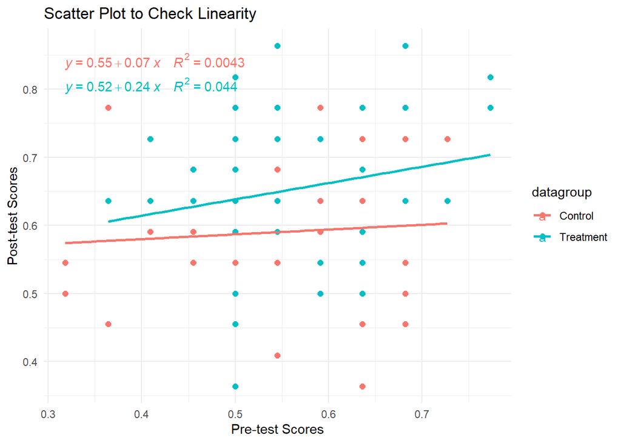

[output not shown]

Then, the assumption of normality of residuals is checked, and its result (with an interpretation) is presented, as shown below.

```
## # Normality of Residuals:
```

```
##
##  Shapiro-Wilk normality test
##
## data:  norm.all.aov$residuals
## W = 0.98491, p-value = 0.3332
```

```
## ## Interpretation: the assumption of normality by group has been met (p>0.05).
```

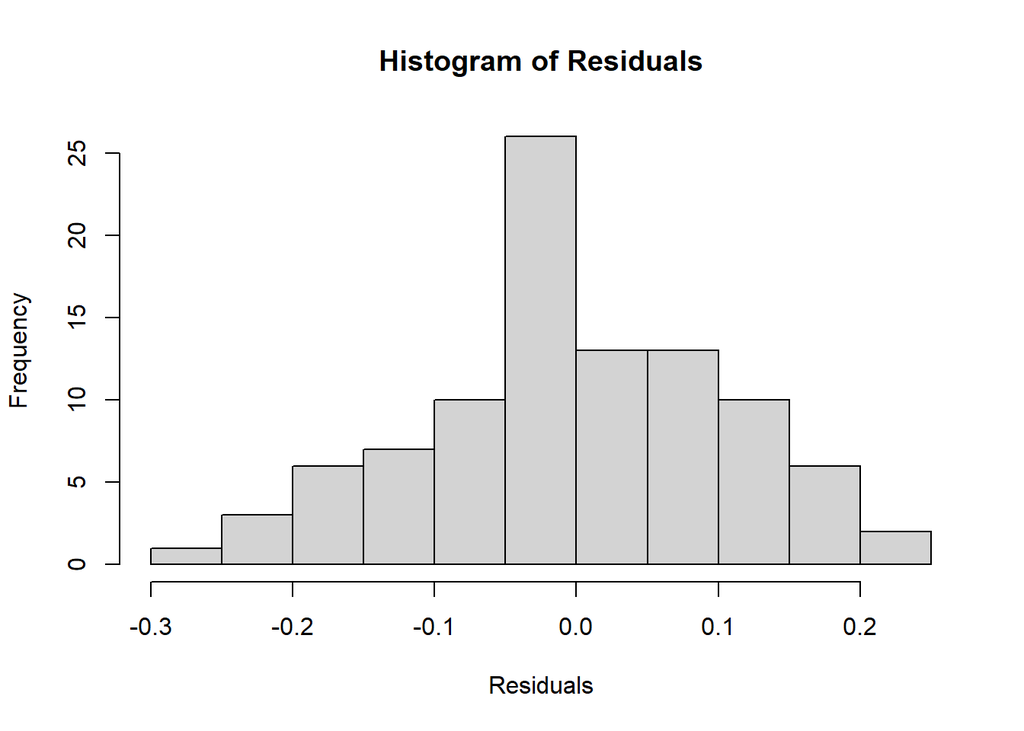

You need to visually examine the histogram (above) and normal Q-Q plot (below) as well to confirm the Shapiro-Wilk normality test result, especially when the sample size is large because the Shapiro-Wilk test becomes very sensitive to a minor deviation from normality at a larger sample size.

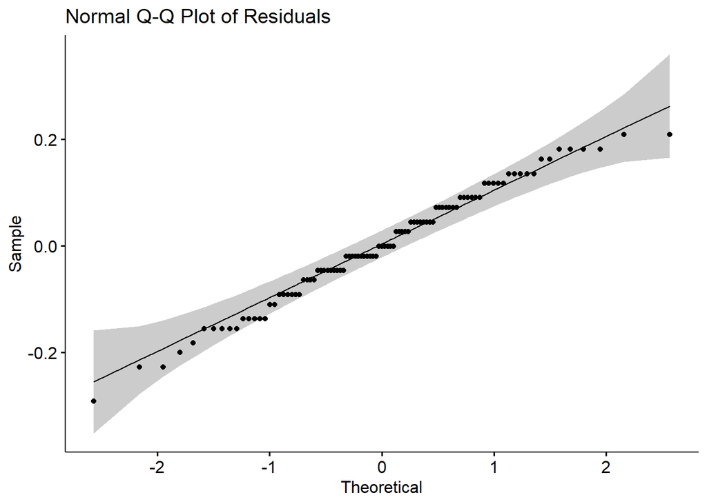

Then, the outputs present the result of checking homogeneity of variance. The function runs Levene Test and reports its result with an interpretation, as shown below.

```
## Levene's Test for Homogeneity of Variance (center = median)
##       Df F value Pr(>F)
## group  1  0.0307 0.8613
##       95
```

```
## ## Interpretation: the assumption of equality of error variances has been met (p>0.05).
```

Then, the function checks the data to see if any outlier exists and reports variables if an outlier is found, as shown below.

```
## [1] avg_score_post avg_score_pre  datagroup      .resid         .cooksd
## [6] .std.resid
## <0 rows> (or 0-length row.names)
```

```
## # Outliers: No outlier has been found.
```

Then, the last assumption of homogeneity of regression line slopes is check, and its results (with an interpretation) are reported, as show below.

```
##
## Call:
## lm(formula = avg_score_post ~ avg_score_pre + datagroup + avg_score_pre:datagroup,
##     data = full_data_binded)
##
## Residuals:
##       Min        1Q    Median        3Q       Max
## -0.274339 -0.074246  0.007143  0.085445  0.214892
##
## Coefficients:
##                                  Estimate Std. Error t value Pr(>|t|)
## (Intercept)                       0.55194    0.08774   6.290 1.02e-08 ***
## avg_score_pre                     0.07016    0.15238   0.460    0.646
## datagroupTreatment               -0.03324    0.13148  -0.253    0.801
## avg_score_pre:datagroupTreatment  0.16914    0.22750   0.743    0.459
## ---
## Signif. codes:  0 '***' 0.001 '**' 0.01 '*' 0.05 '.' 0.1 ' ' 1
##
## Residual standard error: 0.1088 on 93 degrees of freedom
## Multiple R-squared:  0.1014, Adjusted R-squared:  0.07246
## F-statistic:   3.5 on 3 and 93 DF,  p-value: 0.01856
```

```
## ## Interpretation: there was homogeneity of regression slopes as the interaction term (i.e., datagroup:avg_score_pre) was not statistically significant (p>0.05).
```

Third, upon presenting all results of checking the assumptions, the function generates the ANOVA table (type II tests) for you to examine the significance of the group variable.

```
## ANOVA Table (type II tests)
##
##          Effect DFn DFd     F     p p<.05   ges
## 1     datagroup   1  94 8.148 0.005     * 0.080
## 2 avg_score_pre   1  94 1.674 0.199       0.017
```

The function runs a post-hoc analysis to generate estimated (or adjusted) marginal means to compare between the groups and displays/exports a summary statement of the outputs (see the results below).

```
##   avg_score_pre datagroup    emmean         se df  conf.low conf.high
## 1     0.5692887   Control 0.5920313 0.01505694 94 0.5621354 0.6219272
## 2     0.5692887 Treatment 0.6551416 0.01618602 94 0.6230039 0.6872793
##         method
## 1 Emmeans test
## 2 Emmeans test
```

[output not shown]

## One-way Repeated Measures ANOVA Function: “onewayrepeatedanova()”

This function can be used when you collect data from the same students repeatedly at three different time points (e.g., pre-test, post-test, and second post-test) and you want to examine the significance of the changes over time. The function automatically merges pre, post, and post2 datasets, runs the One-way repeated measures ANOVA with assumptions check, and then displays/exports outputs for you all at once. You need to name data files accurately (i.e., “data_treat_pre.csv”, “data_treat_post.csv”, and “data_treat_post2.csv”) and have them saved in the working directory. The outputs/results from this function are as follows.

```r
# You can copy and past the following function in the console panel of RStudio: onewayrepeatedanova()
```

First, the function presents descriptive statistics and boxplots of all three datasets, as shown below.

```
## # A tibble: 3 × 11
##   Time  variable     n   min   max median   iqr  mean    sd    se    ci
##   <fct> <chr>    <dbl> <dbl> <dbl>  <dbl> <dbl> <dbl> <dbl> <dbl> <dbl>
## 1 Pre   Score       45 0.364 0.773  0.545 0.136 0.572 0.097 0.014 0.029
## 2 Post1 Score       45 0.364 0.864  0.636 0.136 0.655 0.111 0.017 0.033
## 3 Post2 Score       45 0.409 0.909  0.682 0.137 0.694 0.121 0.018 0.036
```

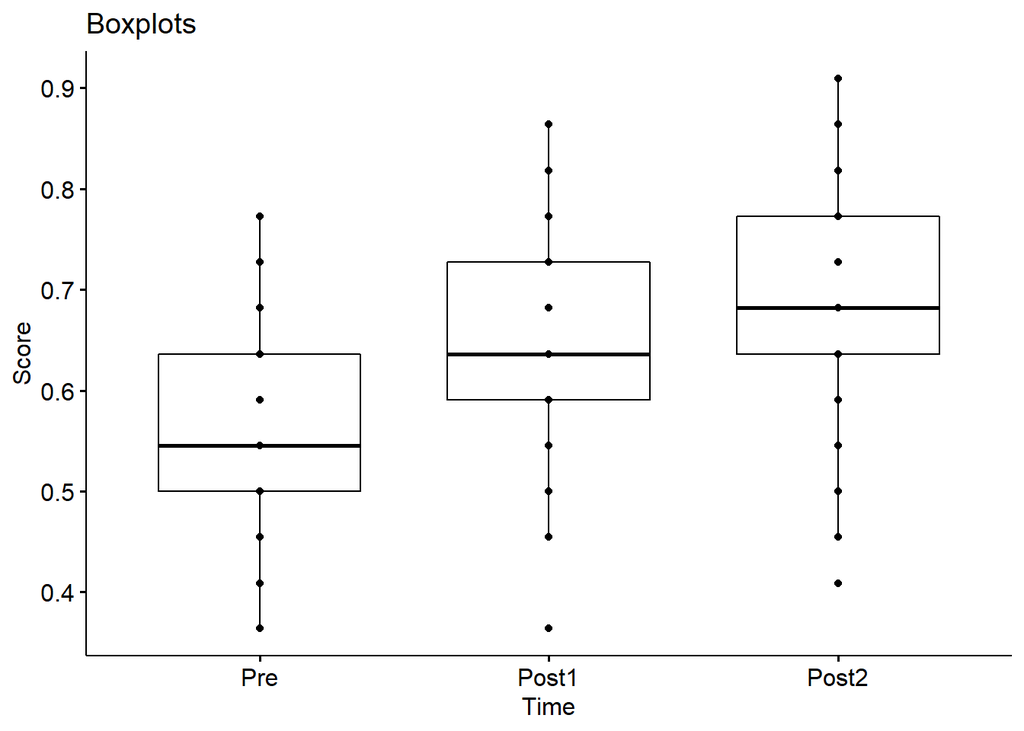

Second, the function runs scripts to check all assumptions to be satisfied and presents the results for you to confidently interpret the results of one-way repeated measures ANOVA. The first assumption checked is no outliers; the result is presented along with an interpretation, as shown below.

```
## ## Interpretation: No extreme outlier was identified in your data.
```

Then, the assumption of normality of residuals is checked, and its result (with an interpretation) is presented, as shown below.

```
##
##  Shapiro-Wilk normality test
##
## data:  resid(res.aov)
## W = 0.98398, p-value = 0.1148
```

```
## --> Interpretation: the residuals were normally distributed (p>0.05).
```

You need to visually examine the histogram and normal Q-Q plot as well to confirm the Shapiro-Wilk normality test result, especially when the sample size is large (e.g., greater than 50) because the Shapiro-Wilk test becomes very sensitive to a minor deviation from normality at a larger sample size.

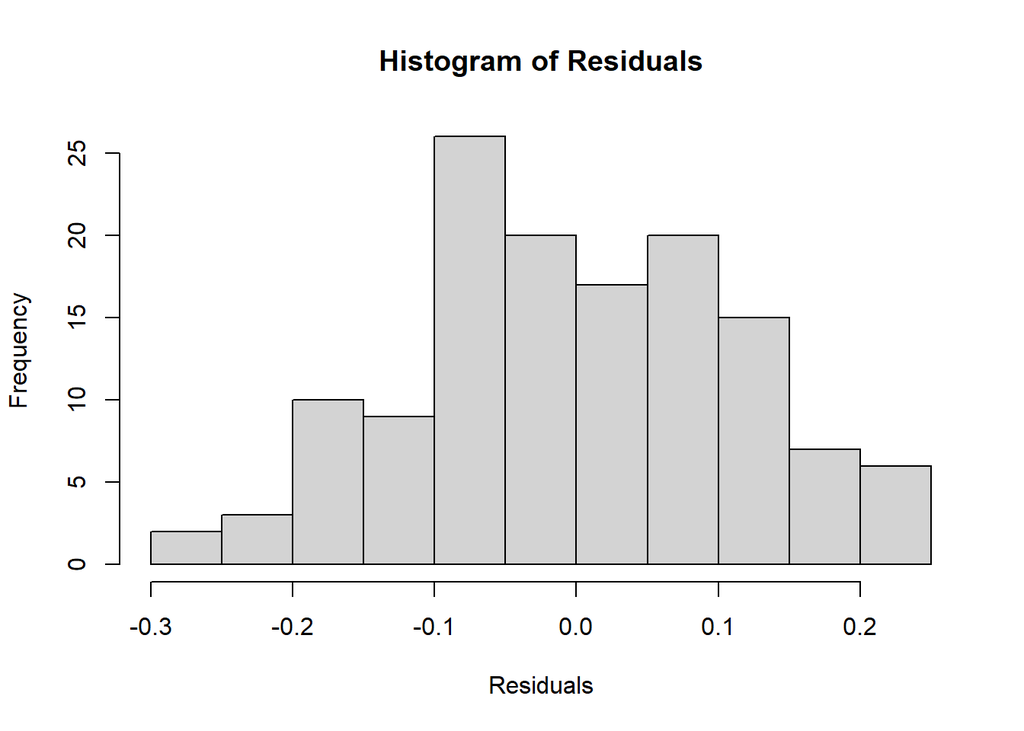

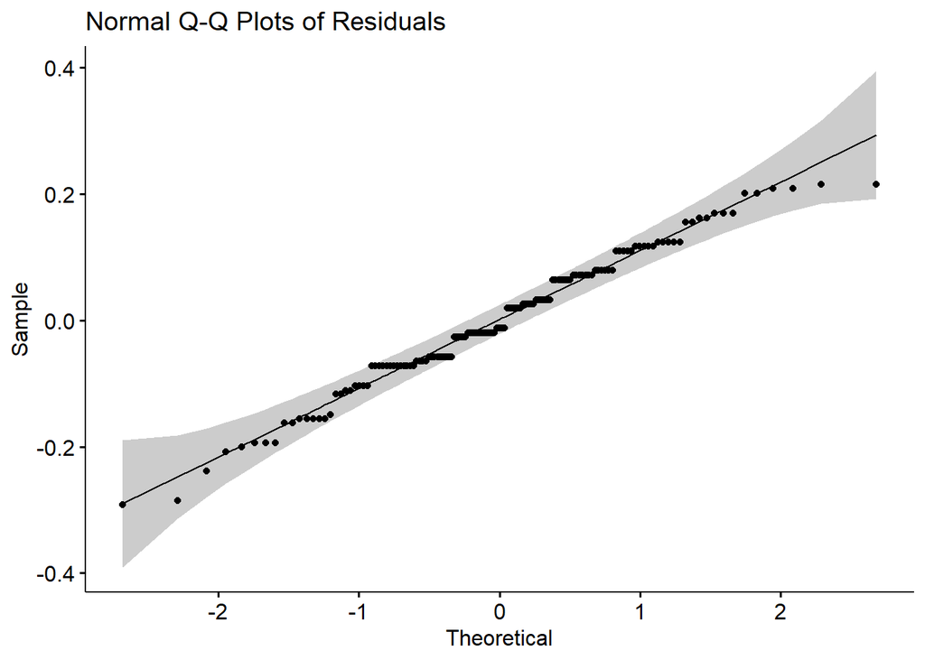

```
## --> Interpretation: if all the points fall in the plots above approximately along the reference line, you can assume normality.
```

Third, the function runs the one-way repeated measures ANOVA and presents its results, as shown below. The assumption of sphericity is checked as part of the computation of this ANOVA test. The Mauchly’s test has been internally run to assess the sphericity assumption. Then, the Greenhouse-Geisser sphericity correction has been automatically applied to factors violating the sphericity of assumption.

```
## ANOVA Table (type III tests)
##
##   Effect  DFn   DFd      F        p p<.05  ges
## 1   Time 1.21 53.06 24.968 1.77e-06     * 0.18
```

```
## --> Interpretation: The average test score at different time points of the intervention are  statistically different: F(1.21 53.06)=24.968, p<0.001, eta2(g)=0.18.
```

Then, if the result above turns out to be significant, then the function proceeds to conduct pairwise comparisons and present the results with an interpretation, as shown below.

```
## # A tibble: 3 × 10
##   .y.   group1 group2    n1    n2 statistic    df         p     p.adj p.adj.si…¹
## * <chr> <chr>  <chr>  <int> <int>     <dbl> <dbl>     <dbl>     <dbl> <chr>
## 1 Score Pre    Post1     45    45     -4.29    44 0.0000963 0.000289  ***
## 2 Score Pre    Post2     45    45     -5.52    44 0.0000017 0.0000051 ****
## 3 Score Post1  Post2     45    45     -4.70    44 0.000026  0.000078  ****
## # … with abbreviated variable name ¹p.adj.signif
```

```
## --> Interpretation for 1: The average pre-test score (0.572) and the average post-test score (0.655) are significantly different. The average post-test score is significantly greater than the average pre-test score (p.adj<0.001).
```

```
## --> Interpretation for 2: The average post1-test score (0.655) and the average post2-test score (0.694) are significantly different. The average post2-test score is significantly greater than the average post-test score (p.adj<0.001).
```

```
## --> Interpretation for 3: The average pre-test score (0.572) and the average post2-test score (0.694) are significantly different. The average post2-test score is significantly greater than the average pre-test score (p.adj<0.001).
```

Fourth, if the normality assumption is violated, the function continues to run the Friedman test, which is the non-parametric version of the parametric one-way repeated measures ANOVA. Although the one-way repeated measures ANOVA is known to be robust to a slight violation of the normality, you may want/need to refer to the result from the non-parametric Friedman test. (The following is just an illuatration of what you will see when the normality assumption is violated; that is, you won’t see this from testing the function with the provided sample data because it satisfies the assumption.)

```
##
##  Friedman rank sum test
##
## data:  avg_score_df
## Friedman chi-squared = 22.419, df = 2, p-value = 1.355e-05
```

```
## --> Interpretation: the median test score is significantly different at the different time points during the intervention (p<0.001).
```

Then, the result of pairwise comparisons with the non-normal data is presented with an interpretation.

```
## # A tibble: 3 × 9
##   .y.   group1 group2    n1    n2 statistic         p     p.adj p.adj.signif
## * <chr> <chr>  <chr>  <int> <int>     <dbl>     <dbl>     <dbl> <chr>
## 1 Score Pre    Post1     45    45      146. 0.000233  0.000699  ***
## 2 Score Pre    Post2     45    45      113  0.0000138 0.0000414 ****
## 3 Score Post1  Post2     45    45        0  0.0000919 0.000276  ***
```

```
## --> Interpretation for 1: the median pre-test score (0.545) and the median post-test score (0.636) are significantly different. The median post-test score is significantly greater than the median pre-test score (p.adj<0.001).
```

```
## --> Interpretation for 2: the median post-test score (0.636) and the median post2-test score (0.682) are significantly different. The median post2-test score is significantly greater than the median post-test score (p.adj<0.001).
```

```
## --> Interpretation for 3: the median pre-test score (0.545) and the median post2-test score (0.682) are significantly different. The median post2-test score is significantly greater than the median pre-test score (p.adj<0.001).
```

## Analysis of Demographic Group Differences Function: “demogroupdiff(csv_data)”

The ‘demogroupdiff()’ function requires users to type a data file name as shown in the sample code below. You can input any of the data file names (i.e., “data_treat_pre.csv”, “data_treat_post.csv”) as they become available for the analysis of demographic group differences. This function automatically combines demographic variables to a dataset, runs the analysis of variance (ANOVA) with assumptions check to examine demographic sub-group differences, and then exports outputs for you all at once. You should have both test data (“data_treat_pre.csv” or “data_treat_post.csv”) and demographic data (“demographic_data.csv”) files in the working directory; please make sure to name data files accurately and have them saved in the working directory.

```r
# You can copy and paste the following function into the console panel of RStudio: demogroupdiff("data_treat_pre.csv") or demogroupdiff("data_treat_post.csv")
```

In addition to the criteria to handle skipped answers (i.e., missing values), this function further asks you to choose a demographic variable to analyze. You will see the demographic group variable names with a numeric code assigned (e.g., gender=1, grade=2). When asked “Enter the number assigned to the demographic variable name you want to analyze,” put the number in the R console and hit the ‘Enter’ key. The function runs all scripts at the back-end and presents/exports the results automatically. The results from this function are as follows.

First, the function presents a summary statistics for each demographic sub-group along with boxplots, as shown below.

```
## # A tibble: 4 × 5
##   group     variable          n  mean    sd
##   <chr>     <chr>         <dbl> <dbl> <dbl>
## 1 Freshman  average_score    11 0.562 0.091
## 2 Junior    average_score    14 0.594 0.103
## 3 Senior    average_score    10 0.532 0.113
## 4 Sophomore average_score    15 0.573 0.087
```

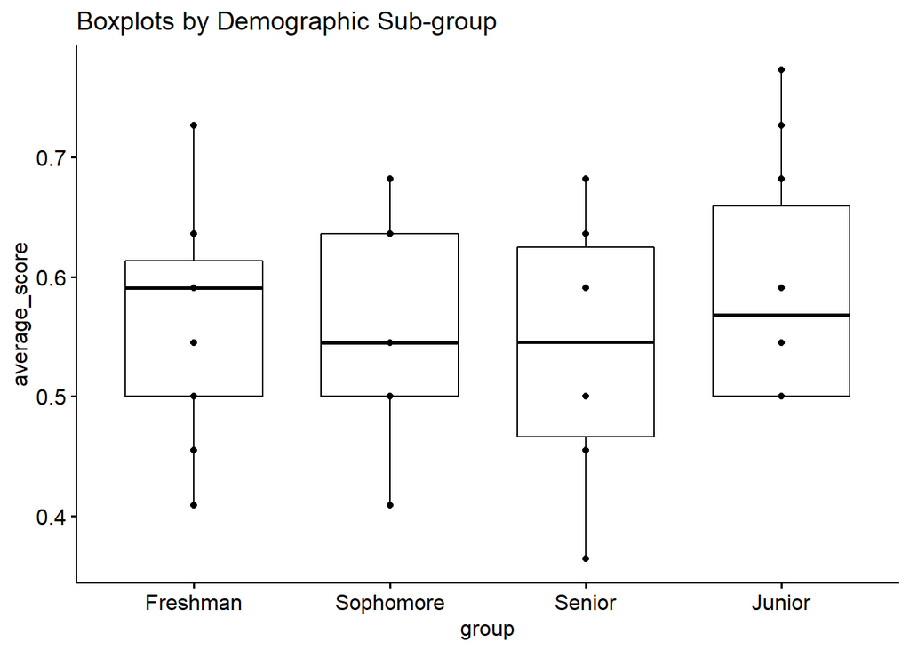

Second, the function continues to test the assumptions for the parametric one-way ANOVA. The first assumption checked is the normality of residuals; the Shapiro-Wilk test is performed, and its result is presented with an interpretation, as shown below.

```
##
##  Shapiro-Wilk normality test
##
## data:  resid(one_way)
## W = 0.96075, p-value = 0.09553
```

```
## ## Interpretation: the assumption of normality by group has been met (p>0.05).
```

If the sample size is greater than 50, it would be better refer to the normal Q-Q plot displayed in the ‘Plots’ panel (exported to an image file named “demogroupdiff_qqplots”) to visually inspect the normality. This is because the Shapiro-Wilk test becomes very sensitive to a minor deviation from normality at a larger sample size. The plot is presented below with a guidance for interpretation.

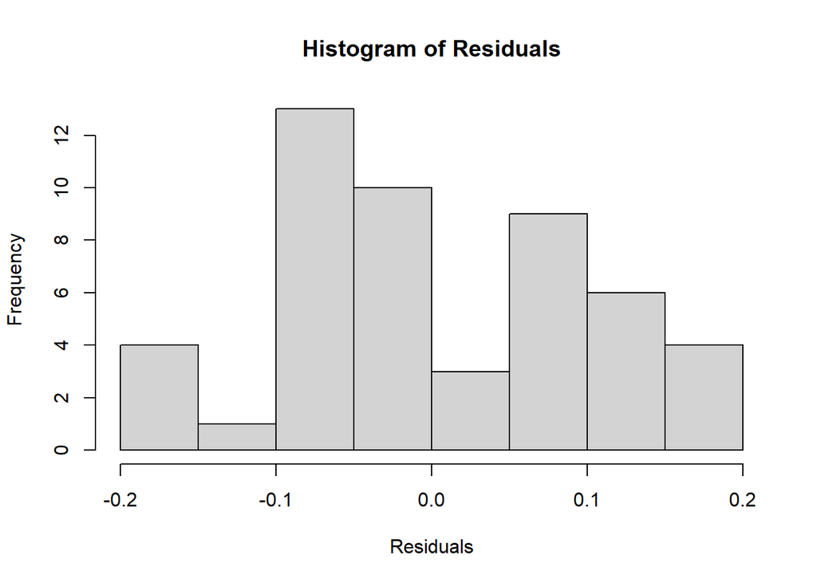

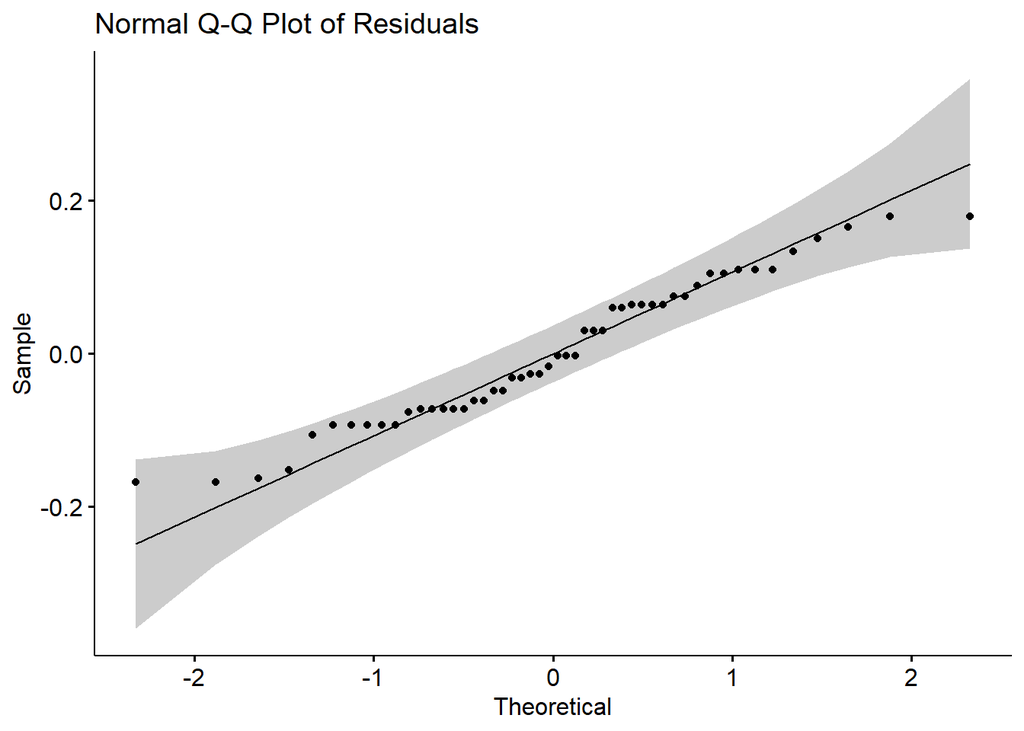

```
## --> Interpretation: if all the points fall in the plots above approximately along the reference line, you can assume normality.
```

The second assumption checked is homogeneity of variance. The result is presented with an interpretation and a visual representation, as shown below.

```
## Levene's Test for Homogeneity of Variance (center = median)
##       Df F value Pr(>F)
## group  3   0.371 0.7743
##       46
```

```
## ## Interpretation: the assumption of equality of variances has been met (p>0.05).
```

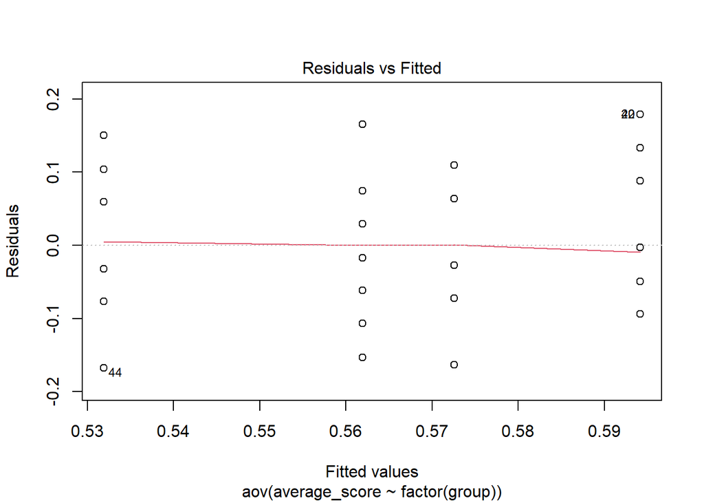

Third, upon presenting the results of assumption checking, the function proceeds to run the one-way ANOVA with equal variances ‘assumed’ or ‘not assumed’ depending on the result of testing homegeneity of variance above. Then, the result with an interpretation is provided, as shown below.

```
## Results of One-way ANOVA: Group Difference(s) (Parametric: Equal variances assumed)
##               Df Sum Sq  Mean Sq F value Pr(>F)
## factor(group)  3 0.0233 0.007775   0.805  0.497
## Residuals     46 0.4442 0.009657
## --> Interpretation: the difference among the demographic sub-groups is not significant (P>0.05).
## Pairwide Comparisons (Equal variances assumed)
```

Then, the function runs scripts to conduct pairwise comparisons and presents the result, as shown below.

```
## Pairwide Comparisons (Equal variances assumed)
##   Tukey multiple comparisons of means
##     95% family-wise confidence level
##
## Fit: aov(formula = average_score ~ factor(group), data = data_original)
##
## $`factor(group)`
##                           diff         lwr        upr     p adj
## Junior-Freshman     0.03223377 -0.07330199 0.13776952 0.8474823
## Senior-Freshman    -0.03000909 -0.14445579 0.08443761 0.8969661
## Sophomore-Freshman  0.01069091 -0.09328546 0.11466728 0.9927074
## Senior-Junior      -0.06224286 -0.17069336 0.04620765 0.4284339
## Sophomore-Junior   -0.02154286 -0.11888016 0.07579445 0.9346245
## Sophomore-Senior    0.04070000 -0.06623364 0.14763364 0.7418160
```

Fourth, in case the normality assumption is violated, the function continues to run the Kruskal-Wallis test, which is the non-parametric version of the parametric one-way ANOVA. Although ANOVA is known to be robust to a slight violation of the normality, you may want/need to refer to the result from the non-parametric Kruskal-Wallis test. (The following is just an illuatration of what you will see when the normality assumption is violated; that is, you won’t see this from testing the function with the provided sample data because it satisfies the assumption.)

```
## Results of Kruskal_Wallis Test (Non-parametric)
```

```
##
##  Kruskal-Wallis rank sum test
##
## data:  average_score by group
## Kruskal-Wallis chi-squared = 1.412, df = 3, p-value = 0.7027
```

```
## Interpretation: The difference among demographic sub-groups is not significant (p>0.05).
```

```
##
##  Pairwise comparisons using Wilcoxon rank sum test with continuity correction
##
## data:  data_original$average_score and data_original$group
##
##           Freshman Junior Senior
## Junior    0.7      -      -
## Senior    0.7      0.7    -
## Sophomore 0.7      0.7    0.7
##
## P value adjustment method: BH
```